# Uine’s IODS course project

Uine Kailamäki

# IODS - Course Project

**Last updated:**

```r
date()
```

```
## [1] "Mon Nov 30 15:51:28 2020"
```

# 1: About the project

The initial setting up of all the necessary tools proved to be a bit of a challenge. R Studio didn’t seem to be able to download all the necessary packages for “knitting” the changes. However, after a rather lengthy troubleshooting session and some help everything finally fell into place.

The R excercises in DataCamp were simple enough, so I do hope that the rest of the course will be a breeze in comparison. :D

Here’s a link to my [repository](https://github.com/Tulikko/IODS-project)!

Learning R was anyway something that I intended to do. After the course I hope to be able to do at least principal component analysis (PCA) and hierarchical cluster analysis (HCA) for our project data without relying on commercial tools.

# 2: Regression and model validation

*Here I describe the work that I have done.*

**Part 1**

[Here](https://github.com/Tulikko/IODS-project/blob/master/data/create_learning2020.R) is the dataset that I wrangled in the previous part of the excercise. The full analysis dataset table can be read with read.table(“data/learning2020.txt”), but that would be a ton of hard-to-read data to display in this diary page, so let’s just take a closer look at the structure and dimensions of what we’ve got.

```r
# assigning the data to something easier to write in codes
lrn2020 <- read.table("data/learning2020.txt")

# dimensions of data: 166 observations and 7 variables
dim(lrn2020)
```

```
## [1] 166   7
```

```r
# structure of data: str() / gives you structural info and the amount of obs. & variables
str(lrn2020)
```

```
## 'data.frame':    166 obs. of  7 variables:
##  $ gender  : chr  "F" "M" "F" "M" ...
##  $ age     : int  53 55 49 53 49 38 50 37 37 42 ...
##  $ attitude: num  3.7 3.1 2.5 3.5 3.7 3.8 3.5 2.9 3.8 2.1 ...
##  $ deep    : num  3.58 2.92 3.5 3.5 3.67 ...
##  $ stra    : num  3.38 2.75 3.62 3.12 3.62 ...
##  $ surf    : num  2.58 3.17 2.25 2.25 2.83 ...
##  $ points  : int  25 12 24 10 22 21 21 31 24 26 ...
```

```r
# structure of data: head() / I like this a bit more than str() for structural info, easier to read!
head(lrn2020)
```

```
##   gender age attitude     deep  stra     surf points
## 1      F  53      3.7 3.583333 3.375 2.583333     25
## 2      M  55      3.1 2.916667 2.750 3.166667     12
## 3      F  49      2.5 3.500000 3.625 2.250000     24
## 4      M  53      3.5 3.500000 3.125 2.250000     10
## 5      M  49      3.7 3.666667 3.625 2.833333     22
## 6      F  38      3.8 4.750000 3.625 2.416667     21
```

**Part 2**

Here I explore the data by summary function and by creating miscellaneous plots. In the graphical overview (produced with the function “ggpairs”) we see that the highest correlation value between two variables is between attitude and points, with correlation value of 0.437 (highest or 100% correlation being 1). I also explored this phenomena by playing around with gendered scatterplots and fitted lines.

```r
# accessing GGally-library
library(GGally)
```

```r
# accessing ggplot2-library
library(ggplot2)

# summary of the data
summary(lrn2020)
```

```
##     gender               age           attitude          deep
##  Length:166         Min.   :17.00   Min.   :1.400   Min.   :1.583
##  Class :character   1st Qu.:21.00   1st Qu.:2.600   1st Qu.:3.333
##  Mode  :character   Median :22.00   Median :3.200   Median :3.667
##                     Mean   :25.51   Mean   :3.143   Mean   :3.680
##                     3rd Qu.:27.00   3rd Qu.:3.700   3rd Qu.:4.083
##                     Max.   :55.00   Max.   :5.000   Max.   :4.917
##       stra            surf           points
##  Min.   :1.250   Min.   :1.583   Min.   : 7.00
##  1st Qu.:2.625   1st Qu.:2.417   1st Qu.:19.00
##  Median :3.188   Median :2.833   Median :23.00
##  Mean   :3.121   Mean   :2.787   Mean   :22.72
##  3rd Qu.:3.625   3rd Qu.:3.167   3rd Qu.:27.75
##  Max.   :5.000   Max.   :4.333   Max.   :33.00
```

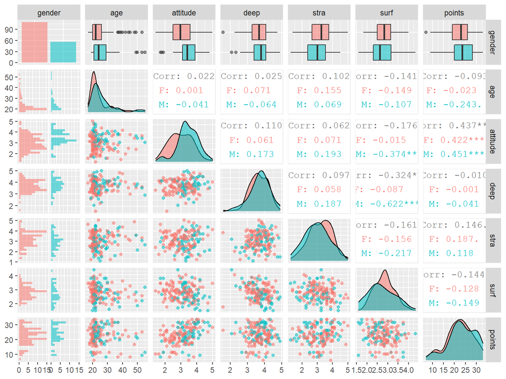

```r
# creating plot matrix "p" to pair variables against each other, to see possible correlations
p <- ggpairs(lrn2020, mapping = aes(col = gender, alpha = 0.3), lower = list(combo = wrap("facethist", bins = 20)))

# printing out the created matrix "p"
p
```

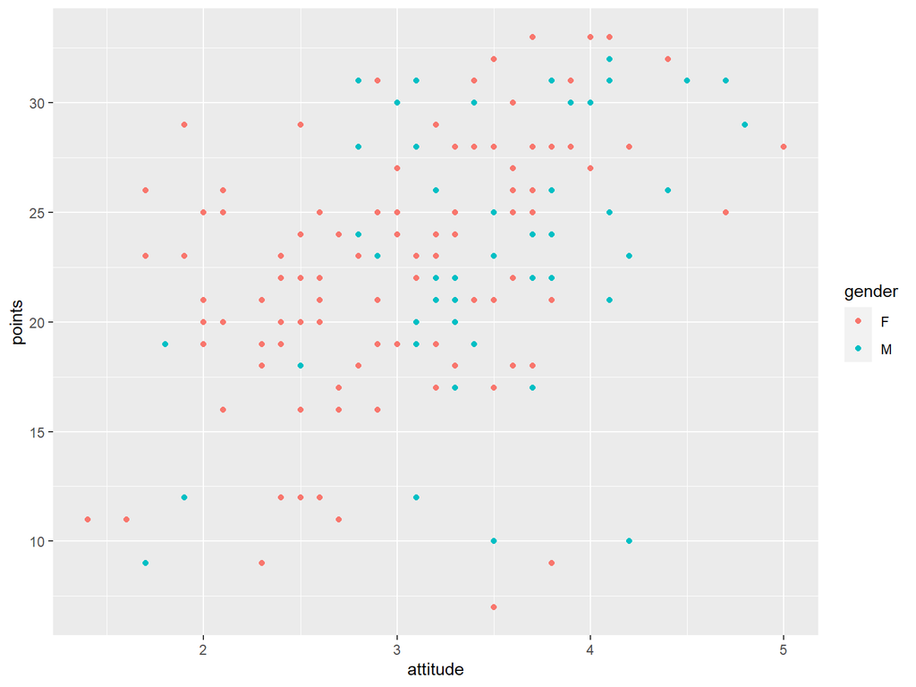

```r
# attitude and points seem to correlate, let's see more closely how the data looks like
ggplot(lrn2020, aes(x = attitude, y = points, col = gender)) + geom_point()
```

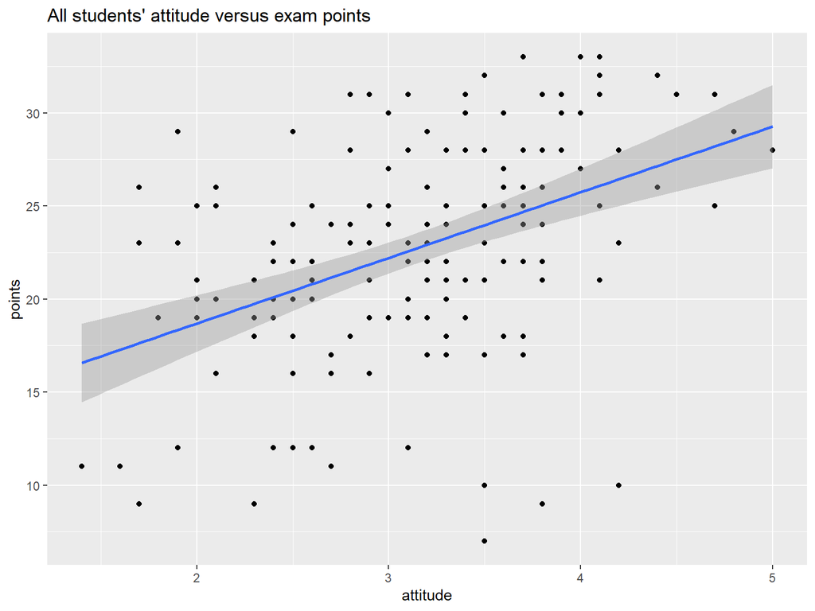

```r
# a scatter plot of points versus attitude + fitted line
qplot(attitude, points, data = lrn2020) + geom_smooth(method = "lm") + ggtitle("All students' attitude versus exam points")
```

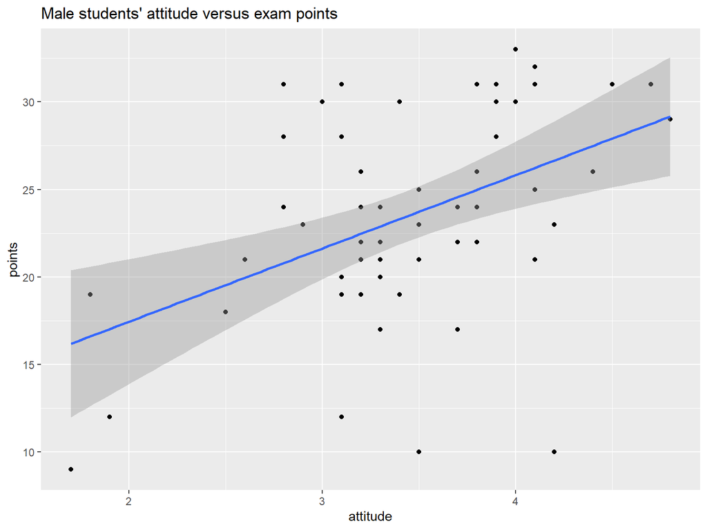

```r
# select male students
m_students <- dplyr::filter(lrn2020, lrn2020$gender == "M")

# plot only male students, points vs. attitude
qplot(attitude, points, data = m_students) + geom_smooth(method = "lm") + ggtitle("Male students' attitude versus exam points")
```

**Part 3**

Based on the previous results, I chose attitude, strategic learning and deep learning as explanatory variables to a regression model (model_x), in which exam points is the target (dependent) variable.

According to the results shown in the summary, deep learning did not have strong significance to the points with a p value of 0.31974. I redid the model (model_y) by discarding deep learning from it.

```r
# creating model with points versus attitude, strategic and deep learning
model_x <- lm(points ~ attitude + stra + deep, data = lrn2020)

summary(model_x)
```

```
##
## Call:
## lm(formula = points ~ attitude + stra + deep, data = lrn2020)
##
## Residuals:
##      Min       1Q   Median       3Q      Max
## -17.5239  -3.4276   0.5474   3.8220  11.5112
##
## Coefficients:
##             Estimate Std. Error t value Pr(>|t|)
## (Intercept)  11.3915     3.4077   3.343  0.00103 **
## attitude      3.5254     0.5683   6.203 4.44e-09 ***
## stra          0.9621     0.5367   1.793  0.07489 .
## deep         -0.7492     0.7507  -0.998  0.31974
## ---
## Signif. codes:  0 '***' 0.001 '**' 0.01 '*' 0.05 '.' 0.1 ' ' 1
##
## Residual standard error: 5.289 on 162 degrees of freedom
## Multiple R-squared:  0.2097, Adjusted R-squared:  0.195
## F-statistic: 14.33 on 3 and 162 DF,  p-value: 2.521e-08
```

```r
# creating adjusted model with points versus attitude and strategic learning
model_y <- lm(points ~ attitude + stra, data = lrn2020)

summary(model_y)
```

```
##
## Call:
## lm(formula = points ~ attitude + stra, data = lrn2020)
##
## Residuals:
##      Min       1Q   Median       3Q      Max
## -17.6436  -3.3113   0.5575   3.7928  10.9295
##
## Coefficients:
##             Estimate Std. Error t value Pr(>|t|)
## (Intercept)   8.9729     2.3959   3.745  0.00025 ***
## attitude      3.4658     0.5652   6.132 6.31e-09 ***
## stra          0.9137     0.5345   1.709  0.08927 .
## ---
## Signif. codes:  0 '***' 0.001 '**' 0.01 '*' 0.05 '.' 0.1 ' ' 1
##
## Residual standard error: 5.289 on 163 degrees of freedom
## Multiple R-squared:  0.2048, Adjusted R-squared:  0.1951
## F-statistic: 20.99 on 2 and 163 DF,  p-value: 7.734e-09
```

**Part 4**

In the adjusted model, attitude and the intercept are clearly significant, but strategic learning (p-value 0.08927) has ~9 % risk of not being significant.

Multiple R-squared -value (0.2048) means that 20,48 % of the total variation in exam points can be explained by this model. The higher this value is, the better the model explains variation.

**Part 5**

In this part I produced a few diagnostic plots: Residuals vs Fitted values, Normal QQ-plot and Residuals vs Leverage.

In linear regression it is assumed that residuals are normally distributed, and the size of the errors do not depend on the variables. “Residuals versus fitted values” shows that there is no trend between these values, which is a positive sign.

“Normal Q-Q” -plot examines the normality assumption of residuals, and it is good if points plot in to the line shown. There is some scatter at the edges, but overall situation is not bad.

“Residuals versus leverage” shows how much single data points deviate the model parameters. In this case, no single observation is shown to have a very strong impact to the parameters.

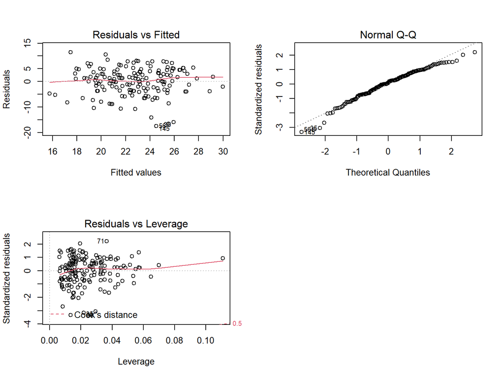

```r
par(mfrow = c(2,2))
plot(model_x, which = c(1,2,5))
```

# 3: Logistic regression

**Part 1**

The existence of this chapter concludes the first part of the exercise.

**Part 2**

This is a joined dataset of math and Portuguese students, aiming to predict the school performance of students by many different variables. Variables are as described [here](https://archive.ics.uci.edu/ml/datasets/Student+Performance), but with the following changes:

Lists were joined by fixed value variables, and the rest variables were combined by averaging; for example, G1—G3 display the averages of 1st, 2nd and final period grades from both math and Portuguese classes. New columns alc_use (average values of students’ weekday and weekend alcohol consumption values, range being 1—5 from low to very high) and high_use (displays if this average alcohol consumption value is higher than 2 or not) were created.

```r
# Reading the wrangled data excel
library(openxlsx); library(dplyr)
alc <- read.xlsx("~/R/IODS-project/data/pormath.xlsx")

# Sneak peek to the dimensions and column names of the wrangled dataset
dim(alc)
```

```
## [1] 370  35
```

```r
colnames(alc)
```

```
##  [1] "school"     "sex"        "age"        "address"    "famsize"
##  [6] "Pstatus"    "Medu"       "Fedu"       "Mjob"       "Fjob"
## [11] "reason"     "guardian"   "traveltime" "studytime"  "schoolsup"
## [16] "famsup"     "activities" "nursery"    "higher"     "internet"
## [21] "romantic"   "famrel"     "freetime"   "goout"      "health"
## [26] "failures"   "paid"       "absences"   "G1"         "G2"
## [31] "G3"         "Dalc"       "Walc"       "alc_use"    "high_use"
```

**Part 3**

The purpose of this exercise is to study how the high/low alcohol consumption relates to a few other variables. I chose variables G3 (= average of the final grade in math and Portuguese courses), absences from school, health, and going out with friends. My hypothesis is that high alcohol consumption correlates *negatively* with higher grades and health, and *positively* with absences from school and going out with friends. I will also explore how alcohol consumption relates to reported study times.

**Part 4**

Let’s explore the chosen variables and their relationship with high/low alcohol consumption!

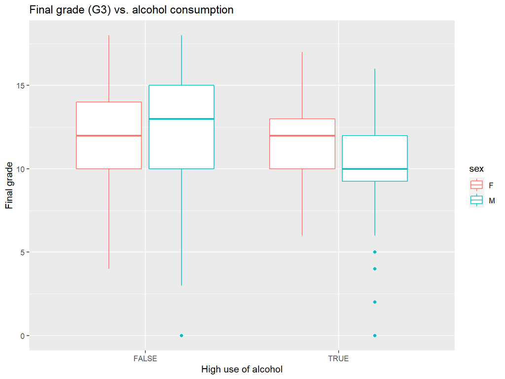

```r
g1 <- ggplot(alc, aes(x = high_use, y = G3, col = sex))
g1 + geom_boxplot() + ggtitle("Final grade (G3) vs. alcohol consumption") + xlab("High use of alcohol") + ylab("Final grade")
```

My hypothesis seems to work in the case of this first variable; higher alcohol consumption correlates indeed with lower grades. However, the effect is much more pronounced in boys than it is in girls.

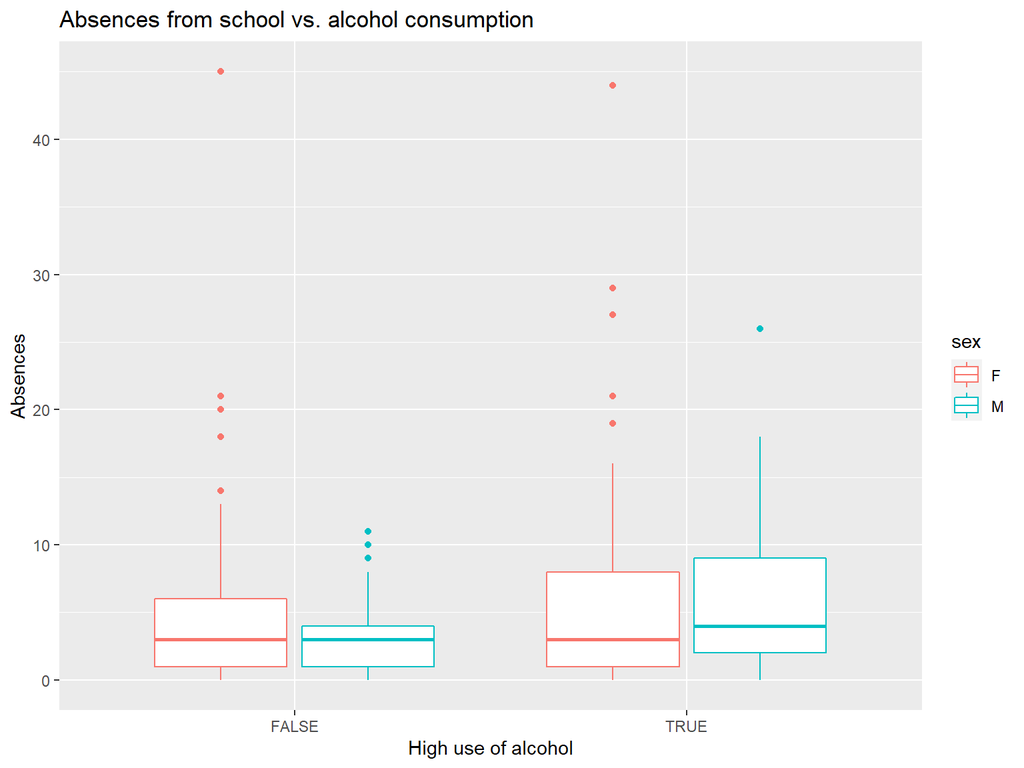

```r
g2 <- ggplot(alc, aes(x = high_use, y = absences, col = sex))
g2 + geom_boxplot() + ggtitle("Absences from school vs. alcohol consumption") + xlab("High use of alcohol") + ylab("Absences")
```

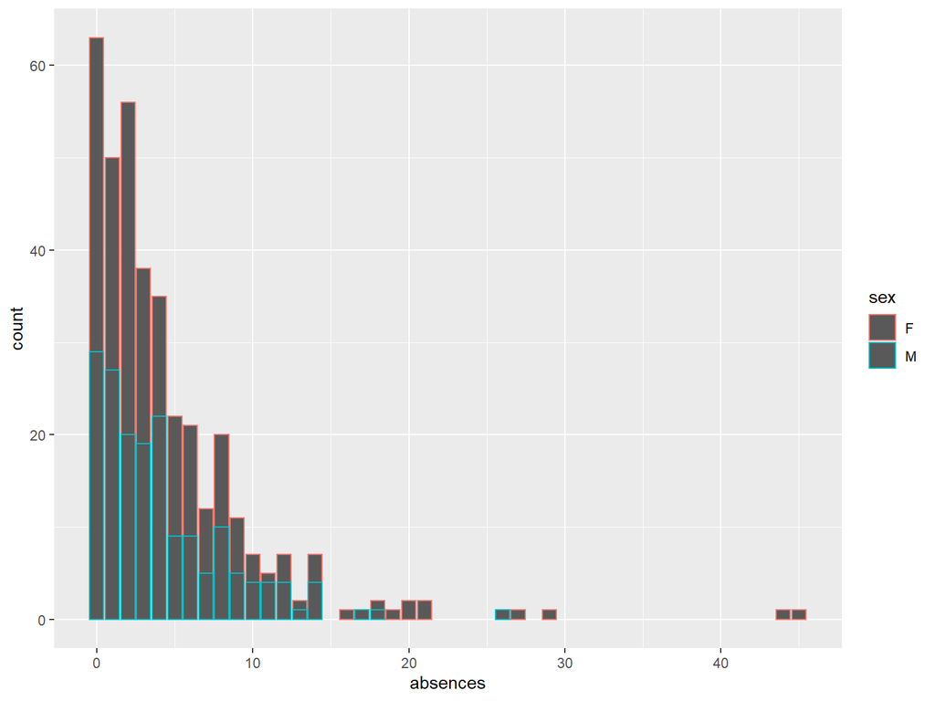

```r
g2_2 <- ggplot(data = alc, aes(x = absences, col=sex))
g2_2 + geom_bar()
```

Second variable supports as well the hypothesis, but the scale in this variable is so big that the few outliers with very high absence values shrink the distribution boxes visually. Bar plot was drawn to display distribution more clearly. Curiously, the alcohol consumption effect was again more pronounced in boys when compared to girls.

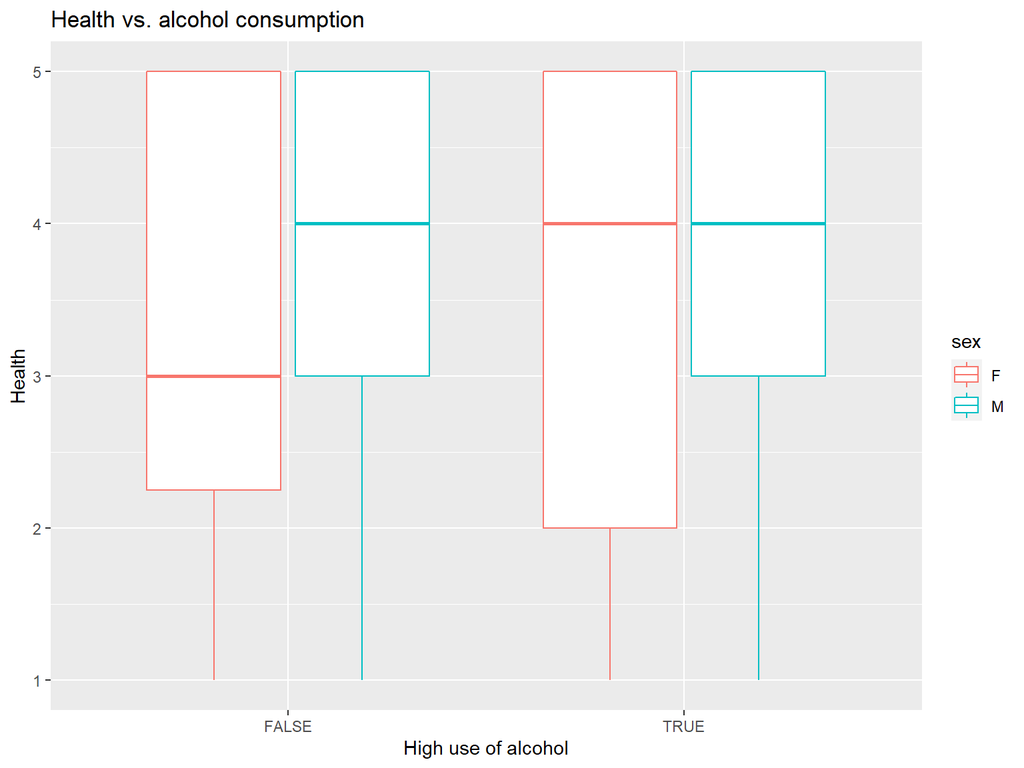

```r
g3 <- ggplot(alc, aes(x = high_use, y = health, col = sex))
g3 + geom_boxplot() + ggtitle("Health vs. alcohol consumption") + xlab("High use of alcohol") + ylab("Health")
```

Third variable proved to be interesting… My hypothesis certainly was not correct on this one, as it seems that boys’ health is not affected at all by high alcohol consumption in these data, and girls median health value is actually *higher* in the high alcohol consumption group, even if the lower quartile is a bit more spread out towards low health values at the same time.

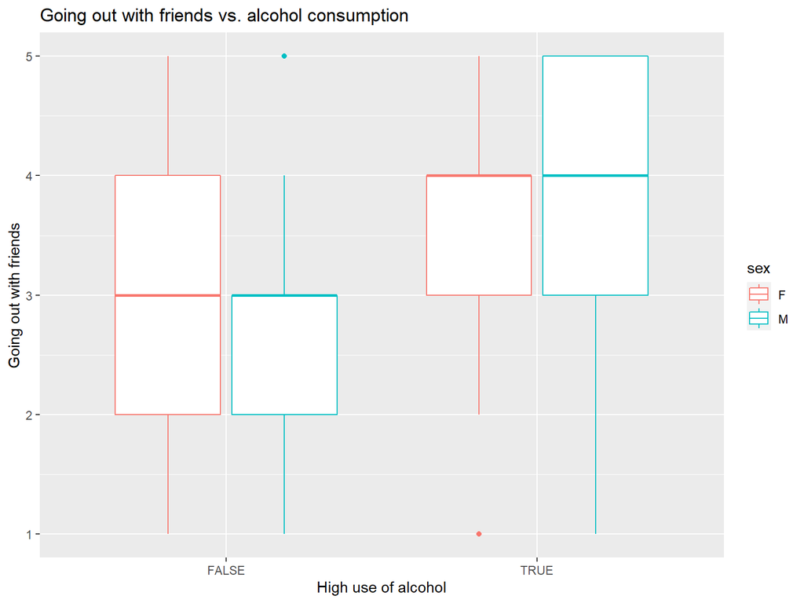

```r
g4 <- ggplot(alc, aes(x = high_use, y = goout, col = sex))
g4 + geom_boxplot() + ggtitle("Going out with friends vs. alcohol consumption") + xlab("High use of alcohol") + ylab("Going out with friends")
```

Fourth, and final, variable - going out with friends - definitely supports the hypothesis. Those students that consume more alcohol have a tendency to go out with their friends more as well.

Finally, I’ll take a look to the relationship between weekly study time and alcohol consumption:

```r
alc %>% group_by(studytime) %>% summarise(alcohol_usage = mean(alc_use))
```

```
## # A tibble: 4 x 2
##   studytime alcohol_usage
##       <dbl>         <dbl>
## 1         1          2.27
## 2         2          1.86
## 3         3          1.52
## 4         4          1.54
```

Clearly, there is a trend where higher study time correlates with lower amount of alcohol consumed. Maybe they don’t have as much time to drink. :)

**Part 5**

Here I fit a logistic regression model to the variables, first including all four from my hypothesis. I will also take a look to the odds ratios for all four of them. Finally, I fit a new model excluding the non-significant variables.

```r
model_alc1 <- glm(high_use ~ G3 + absences + health + goout, data = alc, family = "binomial")
summary(model_alc1)
```

```
##
## Call:
## glm(formula = high_use ~ G3 + absences + health + goout, family = "binomial",
##     data = alc)
##
## Deviance Residuals:
##     Min       1Q   Median       3Q      Max
## -1.8342  -0.7505  -0.5508   0.9357   2.3172
##
## Coefficients:
##             Estimate Std. Error z value Pr(>|z|)
## (Intercept) -3.70363    0.79076  -4.684 2.82e-06 ***
## G3          -0.03852    0.03935  -0.979 0.327587
## absences     0.07436    0.02212   3.362 0.000773 ***
## health       0.15179    0.09209   1.648 0.099275 .
## goout        0.72459    0.11941   6.068 1.29e-09 ***
## ---
## Signif. codes:  0 '***' 0.001 '**' 0.01 '*' 0.05 '.' 0.1 ' ' 1
##
## (Dispersion parameter for binomial family taken to be 1)
##
##     Null deviance: 452.04  on 369  degrees of freedom
## Residual deviance: 386.07  on 365  degrees of freedom
## AIC: 396.07
##
## Number of Fisher Scoring iterations: 4
```

```r
coef(model_alc1)
```

```
## (Intercept)          G3    absences      health       goout
## -3.70363174 -0.03852050  0.07435996  0.15179099  0.72459398
```

From the P-values we can see that absences and going out with friends are statistically significant (P<0.05), and thus the odds ratios and confidence intervals should be significant. Grades (G3) and health are not significant, although health (P=0.09) is not very far. Coefficients (intercept) show the predicted mean value of y when x = 0. Let’s see what the odds ratios and confidence intervals look like:

```r
# odds ratios (OR) & confidence intervals (CI)
OR <- coef(model_alc1) %>% exp
CI <- confint(model_alc1) %>% exp
# Print both
cbind(OR, CI)
```

```
##                    OR       2.5 %    97.5 %
## (Intercept) 0.0246339 0.004960425 0.1109072
## G3          0.9622120 0.890726272 1.0397748
## absences    1.0771945 1.033123265 1.1280521
## health      1.1639169 0.973629481 1.3981834
## goout       2.0638929 1.642693029 2.6260422
```

From odds ratios can be interpreted that students that go out more often are 2.064 times more likely to be heavy drinkers.The more healthy and more absent (from school) ones seem to be just slightly more inclined to report high alcohol use values, and highly scored ones are a bit less (OR<1) likely to be heavy drinkers. The confidence intervals are significant if number 1 cannot be fitted between the 2.5 % and 97.5 % values; this is the case in absences and, especially, in “going out with friends” values.

Right. Let’s see what our model looks like with the two significant variables:

```r
model_alc2 <- glm(high_use ~ absences + goout, data = alc, family = "binomial")
summary(model_alc2)
```

```
##
## Call:
## glm(formula = high_use ~ absences + goout, family = "binomial",
##     data = alc)
##
## Deviance Residuals:
##     Min       1Q   Median       3Q      Max
## -1.9060  -0.7495  -0.5191   0.9438   2.3700
##
## Coefficients:
##             Estimate Std. Error z value Pr(>|z|)
## (Intercept) -3.63280    0.43792  -8.296  < 2e-16 ***
## absences     0.07632    0.02225   3.430 0.000602 ***
## goout        0.73380    0.11786   6.226 4.78e-10 ***
## ---
## Signif. codes:  0 '***' 0.001 '**' 0.01 '*' 0.05 '.' 0.1 ' ' 1
##
## (Dispersion parameter for binomial family taken to be 1)
##
##     Null deviance: 452.04  on 369  degrees of freedom
## Residual deviance: 390.30  on 367  degrees of freedom
## AIC: 396.3
##
## Number of Fisher Scoring iterations: 4
```

P values are very nice now, and Min-Max / 1Q-3Q are not too far off (each pair should be as far from 0, if the model fits well).

**Part 6**

Here I test the predictive power of this model.

```r
# Explore the predictive power of the model: predict the probability of high_use:
probabilities <- predict(model_alc2, type = "response")

# Add the predicted probabilities to the dataset 'alc':
alc <- mutate(alc, probability = probabilities)

# Use the probabilities to make a prediction of high_use:
alc <- mutate(alc, prediction = probability > 0.5)

# Tabulate the target variable versus the predictions:
table(high_use = alc$high_use, prediction = alc$prediction) %>% addmargins()
```

```
##         prediction
## high_use FALSE TRUE Sum
##    FALSE   236   23 259
##    TRUE     65   46 111
##    Sum     301   69 370
```

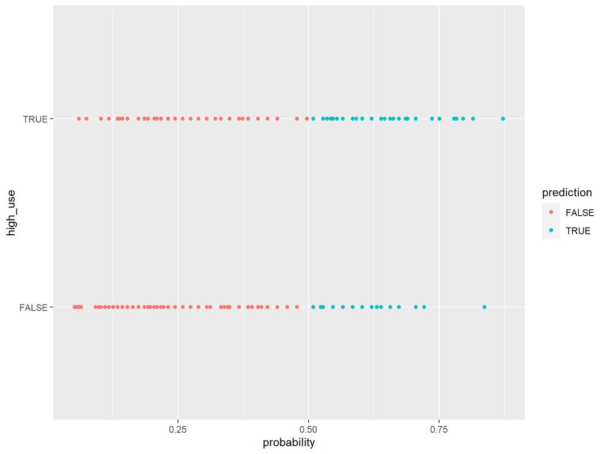

```r
# plot of 'high_use' versus 'probability' in 'alc'
g <- ggplot(alc, aes(x = probability, y = high_use, col = prediction))
g + geom_point()
```

Here the same phenomena is illustrated graphically. There are less wrong predictions in the low (“false”) alcohol consumption group than there are in the high usage group.

```r
# loss function (= mean prediction error)
loss_func <- function(class, prob) {
  n_wrong <- abs(class - prob) > 0.5
  mean(n_wrong)}

# Average number of wrong predictions in the (training) data
loss_func(class = alc$high_use, prob = alc$probability)
```

```
## [1] 0.2378378
```

```r
# Comparing the result to a prediction that there would have been no high-users:
loss_func(class = alc$high_use, prob = 0)
```

```
## [1] 0.3
```

```r
loss_func(class = alc$high_use, prob = 1)
```

```
## [1] 0.7
```

```r
loss_func(class = alc$high_use, prob = 2)
```

```
## [1] 1
```

**Part 7**

Simple 10-fold cross-validation

```r
# K-fold cross-validation
library(boot)
cv <- cv.glm(data = alc, cost = loss_func, glmfit = model_alc2, K = 10)

# average number of wrong predictions in the cross validation
cv$delta[1]
```

```
## [1] 0.2297297
```

# 4: Clustering and classification

**Part 1**

In this exercise we created ‘chapter4.Rmd’ to perform the clustering and classification analysis in.

**Part 2**

Here I initialize the necessary libraries and load the analysis data from MASS library. The dataset consists of 14 variables with 506 observations about housing values in suburbs of Boston.

```r
# Libraries
library(MASS)
library(corrplot)
library(dplyr)
library(ggplot2)
library(GGally)

# Load the Boston data from MASS:
data("Boston")
```

The variables are **crim** (crime rate), **zn** (residential land), **indus** (non-retail business acres), **chas** (dummy variable), **nox** (nitrogen oxides concentration in ppm), **rm** (average rooms), **age** (built prior to 1940), **dis** (distances to employment centres), **rad** (accessibility to radial highways), **tax** (tax rate), **ptratio** (pupil-teacher ratio), **black** (relative proportion of blacks), **lstat** (lower status %) and **medv** (owner-occupied homes).

```r
# Exploring the data:
dim(Boston)
```

```
## [1] 506  14
```

```r
str(Boston)
```

```
## 'data.frame':    506 obs. of  14 variables:
##  $ crim   : num  0.00632 0.02731 0.02729 0.03237 0.06905 ...
##  $ zn     : num  18 0 0 0 0 0 12.5 12.5 12.5 12.5 ...
##  $ indus  : num  2.31 7.07 7.07 2.18 2.18 2.18 7.87 7.87 7.87 7.87 ...
##  $ chas   : int  0 0 0 0 0 0 0 0 0 0 ...
##  $ nox    : num  0.538 0.469 0.469 0.458 0.458 0.458 0.524 0.524 0.524 0.524 ...
##  $ rm     : num  6.58 6.42 7.18 7 7.15 ...
##  $ age    : num  65.2 78.9 61.1 45.8 54.2 58.7 66.6 96.1 100 85.9 ...
##  $ dis    : num  4.09 4.97 4.97 6.06 6.06 ...
##  $ rad    : int  1 2 2 3 3 3 5 5 5 5 ...
##  $ tax    : num  296 242 242 222 222 222 311 311 311 311 ...
##  $ ptratio: num  15.3 17.8 17.8 18.7 18.7 18.7 15.2 15.2 15.2 15.2 ...
##  $ black  : num  397 397 393 395 397 ...
##  $ lstat  : num  4.98 9.14 4.03 2.94 5.33 ...
##  $ medv   : num  24 21.6 34.7 33.4 36.2 28.7 22.9 27.1 16.5 18.9 ...
```

**Part 3**

Here we explore the dataset a bit further by showing summary of the variables, and then exploring correlations between variables both numerically and visually.

```r
# Summary of the variables
summary(Boston)
```

```
##       crim                zn             indus            chas
##  Min.   : 0.00632   Min.   :  0.00   Min.   : 0.46   Min.   :0.00000
##  1st Qu.: 0.08205   1st Qu.:  0.00   1st Qu.: 5.19   1st Qu.:0.00000
##  Median : 0.25651   Median :  0.00   Median : 9.69   Median :0.00000
##  Mean   : 3.61352   Mean   : 11.36   Mean   :11.14   Mean   :0.06917
##  3rd Qu.: 3.67708   3rd Qu.: 12.50   3rd Qu.:18.10   3rd Qu.:0.00000
##  Max.   :88.97620   Max.   :100.00   Max.   :27.74   Max.   :1.00000
##       nox               rm             age              dis
##  Min.   :0.3850   Min.   :3.561   Min.   :  2.90   Min.   : 1.130
##  1st Qu.:0.4490   1st Qu.:5.886   1st Qu.: 45.02   1st Qu.: 2.100
##  Median :0.5380   Median :6.208   Median : 77.50   Median : 3.207
##  Mean   :0.5547   Mean   :6.285   Mean   : 68.57   Mean   : 3.795
##  3rd Qu.:0.6240   3rd Qu.:6.623   3rd Qu.: 94.08   3rd Qu.: 5.188
##  Max.   :0.8710   Max.   :8.780   Max.   :100.00   Max.   :12.127
##       rad              tax           ptratio          black
##  Min.   : 1.000   Min.   :187.0   Min.   :12.60   Min.   :  0.32
##  1st Qu.: 4.000   1st Qu.:279.0   1st Qu.:17.40   1st Qu.:375.38
##  Median : 5.000   Median :330.0   Median :19.05   Median :391.44
##  Mean   : 9.549   Mean   :408.2   Mean   :18.46   Mean   :356.67
##  3rd Qu.:24.000   3rd Qu.:666.0   3rd Qu.:20.20   3rd Qu.:396.23
##  Max.   :24.000   Max.   :711.0   Max.   :22.00   Max.   :396.90
##      lstat            medv
##  Min.   : 1.73   Min.   : 5.00
##  1st Qu.: 6.95   1st Qu.:17.02
##  Median :11.36   Median :21.20
##  Mean   :12.65   Mean   :22.53
##  3rd Qu.:16.95   3rd Qu.:25.00
##  Max.   :37.97   Max.   :50.00
```

```r
# Calculating correlation matrix and rounding it
cor_matrix<-cor(Boston) %>% round(digits = 2)

# Printing the matrix
cor_matrix
```

```
##          crim    zn indus  chas   nox    rm   age   dis   rad   tax ptratio
## crim     1.00 -0.20  0.41 -0.06  0.42 -0.22  0.35 -0.38  0.63  0.58    0.29
## zn      -0.20  1.00 -0.53 -0.04 -0.52  0.31 -0.57  0.66 -0.31 -0.31   -0.39
## indus    0.41 -0.53  1.00  0.06  0.76 -0.39  0.64 -0.71  0.60  0.72    0.38
## chas    -0.06 -0.04  0.06  1.00  0.09  0.09  0.09 -0.10 -0.01 -0.04   -0.12
## nox      0.42 -0.52  0.76  0.09  1.00 -0.30  0.73 -0.77  0.61  0.67    0.19
## rm      -0.22  0.31 -0.39  0.09 -0.30  1.00 -0.24  0.21 -0.21 -0.29   -0.36
## age      0.35 -0.57  0.64  0.09  0.73 -0.24  1.00 -0.75  0.46  0.51    0.26
## dis     -0.38  0.66 -0.71 -0.10 -0.77  0.21 -0.75  1.00 -0.49 -0.53   -0.23
## rad      0.63 -0.31  0.60 -0.01  0.61 -0.21  0.46 -0.49  1.00  0.91    0.46
## tax      0.58 -0.31  0.72 -0.04  0.67 -0.29  0.51 -0.53  0.91  1.00    0.46
## ptratio  0.29 -0.39  0.38 -0.12  0.19 -0.36  0.26 -0.23  0.46  0.46    1.00
## black   -0.39  0.18 -0.36  0.05 -0.38  0.13 -0.27  0.29 -0.44 -0.44   -0.18
## lstat    0.46 -0.41  0.60 -0.05  0.59 -0.61  0.60 -0.50  0.49  0.54    0.37
## medv    -0.39  0.36 -0.48  0.18 -0.43  0.70 -0.38  0.25 -0.38 -0.47   -0.51
##         black lstat  medv
## crim    -0.39  0.46 -0.39
## zn       0.18 -0.41  0.36
## indus   -0.36  0.60 -0.48
## chas     0.05 -0.05  0.18
## nox     -0.38  0.59 -0.43
## rm       0.13 -0.61  0.70
## age     -0.27  0.60 -0.38
## dis      0.29 -0.50  0.25
## rad     -0.44  0.49 -0.38
## tax     -0.44  0.54 -0.47
## ptratio -0.18  0.37 -0.51
## black    1.00 -0.37  0.33
## lstat   -0.37  1.00 -0.74
## medv     0.33 -0.74  1.00
```

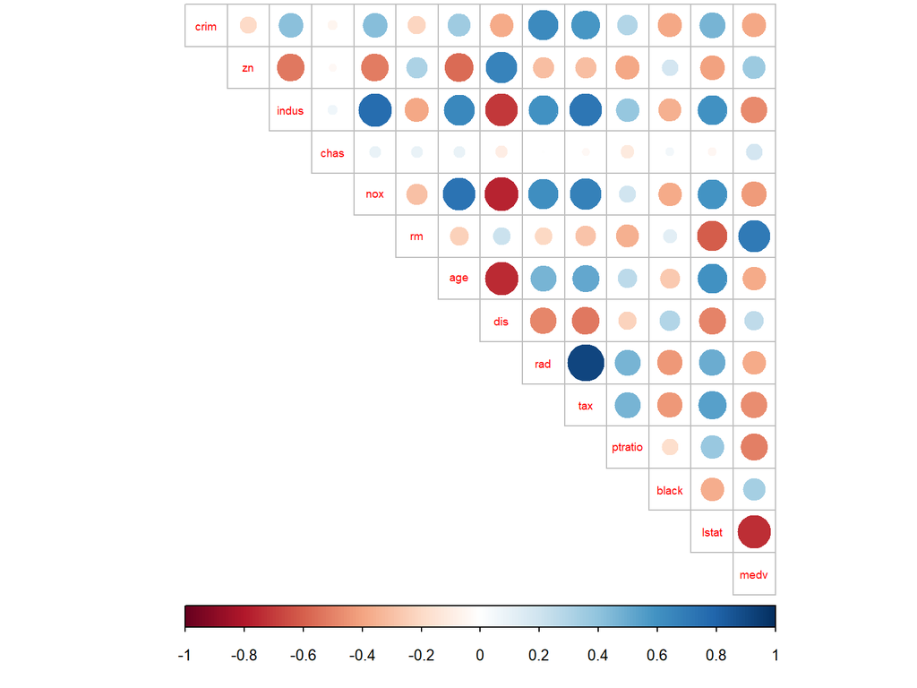

```r
# Visualizing the matrix
corrplot(cor_matrix, method="circle", type="upper", cl.pos="b", tl.pos="d", tl.cex = 0.6)
```

The correlation plot sure is pretty, and it seems like strongest correlation with our variable of interest, crime rate (crim), is with “tax” and “rad” variables.

**Part 4**

In this part we standardize the dataset to have more comparable values. If one variable has huge values with big differences, and other has intrinsically very small values with equally small differences, we might miss correlations between them as the bigger scale completely dominates the output.

There are different ways to rescale or “normalize” data for analysis. Here we use the most common way, the “z-score”, which represents the amount of standard deviations by which the observation differs from the mean value. It can have positive or negative value. Point is, when all data is rescaled like this, we get comparable results for clustering.

$$scaled(x)=\frac{x-mean(x)}{sd(x)}$$

```r
# Scaling the data
boston_scaled <- scale(Boston)

# Changing the class to data frame from "matrix" "array"
boston_scaled <- as.data.frame(boston_scaled)

# Summary of the scaled variables
summary(boston_scaled)
```

```
##       crim                 zn               indus              chas
##  Min.   :-0.419367   Min.   :-0.48724   Min.   :-1.5563   Min.   :-0.2723
##  1st Qu.:-0.410563   1st Qu.:-0.48724   1st Qu.:-0.8668   1st Qu.:-0.2723
##  Median :-0.390280   Median :-0.48724   Median :-0.2109   Median :-0.2723
##  Mean   : 0.000000   Mean   : 0.00000   Mean   : 0.0000   Mean   : 0.0000
##  3rd Qu.: 0.007389   3rd Qu.: 0.04872   3rd Qu.: 1.0150   3rd Qu.:-0.2723
##  Max.   : 9.924110   Max.   : 3.80047   Max.   : 2.4202   Max.   : 3.6648
##       nox                rm               age               dis
##  Min.   :-1.4644   Min.   :-3.8764   Min.   :-2.3331   Min.   :-1.2658
##  1st Qu.:-0.9121   1st Qu.:-0.5681   1st Qu.:-0.8366   1st Qu.:-0.8049
##  Median :-0.1441   Median :-0.1084   Median : 0.3171   Median :-0.2790
##  Mean   : 0.0000   Mean   : 0.0000   Mean   : 0.0000   Mean   : 0.0000
##  3rd Qu.: 0.5981   3rd Qu.: 0.4823   3rd Qu.: 0.9059   3rd Qu.: 0.6617
##  Max.   : 2.7296   Max.   : 3.5515   Max.   : 1.1164   Max.   : 3.9566
##       rad               tax             ptratio            black
##  Min.   :-0.9819   Min.   :-1.3127   Min.   :-2.7047   Min.   :-3.9033
##  1st Qu.:-0.6373   1st Qu.:-0.7668   1st Qu.:-0.4876   1st Qu.: 0.2049
##  Median :-0.5225   Median :-0.4642   Median : 0.2746   Median : 0.3808
##  Mean   : 0.0000   Mean   : 0.0000   Mean   : 0.0000   Mean   : 0.0000
##  3rd Qu.: 1.6596   3rd Qu.: 1.5294   3rd Qu.: 0.8058   3rd Qu.: 0.4332
##  Max.   : 1.6596   Max.   : 1.7964   Max.   : 1.6372   Max.   : 0.4406
##      lstat              medv
##  Min.   :-1.5296   Min.   :-1.9063
##  1st Qu.:-0.7986   1st Qu.:-0.5989
##  Median :-0.1811   Median :-0.1449
##  Mean   : 0.0000   Mean   : 0.0000
##  3rd Qu.: 0.6024   3rd Qu.: 0.2683
##  Max.   : 3.5453   Max.   : 2.9865
```

The values are much more comparable now. Let’s create a categorical variable of the crime rate (“crim”). We use the quantiles as break points in the categorical variable (0 %/25 %/50 %/75 %/100 %) and drop the old crime rate variable. Finally, we divide the dataset to “train” and “test” sets, with 80% of the data in the “train” set.

```r
# Quantile vector of variable 'crim':
bins <- quantile(boston_scaled$crim)
bins
```

```
##           0%          25%          50%          75%         100%
## -0.419366929 -0.410563278 -0.390280295  0.007389247  9.924109610
```

```r
# Categorical variable 'crime':
crime <- cut(boston_scaled$crim, breaks = bins, include.lowest = TRUE, label = c("low","med_low","med_high","high"))

# Removing original 'crim'
boston_scaled <- dplyr::select(boston_scaled, -crim)

# Adding 'crime'
boston_scaled <- data.frame(boston_scaled, crime)

# Choosing randomly 80% of the rows:
n <- nrow(boston_scaled)
ind <- sample(n,  size = n * 0.8)

# Dividing to train and test sets:
train <- boston_scaled[ind,]
test <- boston_scaled[-ind,]
```

**Part 5**

Here we perform the linear discriminant analysis of how the crime rate classes (broken into “low”,“med_low”,“med_high” and “high” in the previous part) cluster, and visualize results in a biplot.

```r
# Linear discriminant analysis
lda.fit <- lda(crime ~ ., data = train)
lda.fit
```

```
## Call:
## lda(crime ~ ., data = train)
##
## Prior probabilities of groups:
##       low   med_low  med_high      high
## 0.2623762 0.2376238 0.2425743 0.2574257
##
## Group means:
##                   zn      indus         chas        nox          rm        age
## low       1.04238143 -0.9325646 -0.086616792 -0.8903237  0.44873676 -0.9153624
## med_low  -0.07008138 -0.2384030 -0.108283225 -0.5168728 -0.12238323 -0.3184300
## med_high -0.38048487  0.2049720  0.129415854  0.4398449  0.06262054  0.4134577
## high     -0.48724019  1.0170690 -0.007331936  1.0271702 -0.44146726  0.8104954
##                 dis        rad        tax     ptratio       black       lstat
## low       0.8799321 -0.7045056 -0.7187341 -0.44703099  0.37597050 -0.78124412
## med_low   0.3435950 -0.5308586 -0.4372656 -0.04874654  0.30020890 -0.15098139
## med_high -0.3672855 -0.3853715 -0.2658072 -0.29289653  0.06860869 -0.00108627
## high     -0.8470048  1.6386213  1.5144083  0.78135074 -0.78048974  0.94225032
##                   medv
## low       0.4997702446
## med_low   0.0001705619
## med_high  0.1098227017
## high     -0.6836515012
##
## Coefficients of linear discriminants:
##                 LD1          LD2         LD3
## zn       0.10077845  0.809863173 -0.90554366
## indus   -0.01606022 -0.398146532  0.50072596
## chas    -0.09444947  0.007868916  0.04363681
## nox      0.40411920 -0.677903558 -1.38526154
## rm      -0.08678409 -0.031515022 -0.15477981
## age      0.29757141 -0.363667087 -0.11398009
## dis     -0.08808224 -0.497611993  0.37378393
## rad      2.98238398  0.799565861  0.05436670
## tax      0.01714885  0.109664290  0.34342206
## ptratio  0.11836585  0.086693532 -0.24101563
## black   -0.13782156  0.026059682  0.13953873
## lstat    0.18671389 -0.154207898  0.45835336
## medv     0.19420339 -0.393039091 -0.06603435
##
## Proportion of trace:
##    LD1    LD2    LD3
## 0.9457 0.0415 0.0127
```

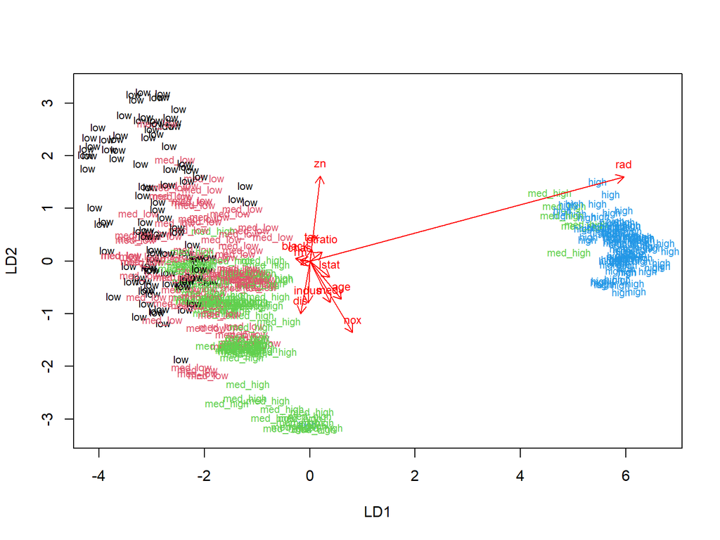

```r
# Function for LDA biplot arrows
lda.arrows <- function(x, myscale = 1, arrow_heads = 0.1, color = "red", tex = 0.75, choices = c(1,2)){
  heads <- coef(x)
  arrows(x0 = 0, y0 = 0,
         x1 = myscale * heads[,choices[1]],
         y1 = myscale * heads[,choices[2]], col=color, length = arrow_heads)
  text(myscale * heads[,choices], labels = row.names(heads),
       cex = tex, col=color, pos=3)
}

# Target classes as numeric
classes <- as.numeric(train$crime)

# Plot the LDA results
plot(lda.fit, dimen = 2, col = classes, pch = classes)
lda.arrows(lda.fit, myscale = 2)
```

If I understand the plot correctly, variable “rad” (accessibility to radial highways) is very strong indicator of high (blue) crime rate values. High “zn” (residential land) value is somewhat indicative of low (black) values, and “nox” (nitrogen oxides) correlates most to med_high crime rate values.

**Part 6**

In this part we predict the classes with the LDA model on the test data, and cross tabulate the results with the crime categories from the “test” set.

```r
# Save the correct classes from test data:
correct_classes <- test$crime

# Remove the crime variable from test data:
test <- dplyr::select(test, -crime)

# Predict classes with test data:
lda.pred <- predict(lda.fit, newdata = test)

# Cross-tabulate the results:
table(correct = correct_classes, predicted = lda.pred$class)
```

```
##           predicted
## correct    low med_low med_high high
##   low       10       8        3    0
##   med_low    3      25        2    0
##   med_high   1       9       18    0
##   high       0       0        0   23
```

**Part 7**

The optimal amount of clusters is when the value of total Within Sum of Squares (“tWCSS”) changes abruptly. With this data, the optimal number of clusters is 2.

From the two visualization plots (ggpairs) for two different K means cluster analysis results, with different number of clusters, we can easily see the difference. The latter one with only 2 clusters is visually much more convincing in its interpreted clusters than the one with 3 clusters.

```r
# Reload data
data('Boston')

# Standardizing and changing class to data frame
boston_scaled <- scale(Boston)
boston_scaled <- as.data.frame(boston_scaled)

# Euclidean distance matrix
dist_eu <- dist(boston_scaled)
summary(dist_eu)
```

```
##    Min. 1st Qu.  Median    Mean 3rd Qu.    Max.
##  0.1343  3.4625  4.8241  4.9111  6.1863 14.3970
```

```r
# Manhattan distance matrix
dist_man <- dist(Boston, method = 'manhattan')
summary(dist_man)
```

```
##     Min.  1st Qu.   Median     Mean  3rd Qu.     Max.
##    2.016  149.145  279.505  342.899  509.707 1198.265
```

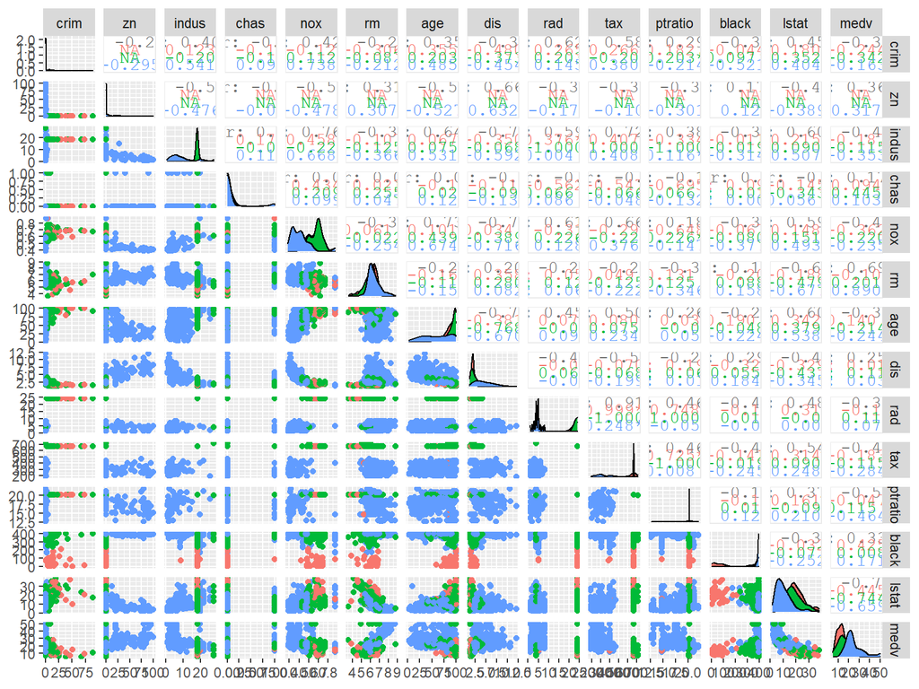

```r
# Set seed to remove randomness between runs
set.seed(123)

# Maximum number of clusters
k_max <- 6

# K-means clustering, 1st attempt before determining optimal nr of clusters
km1 <-kmeans(Boston, centers = 3)

# Visualization by ggpairs, using different colours for different clusters
cluster1 <- as.factor(km1$cluster)
ggpairs(Boston, mapping = aes(col = cluster1))
```

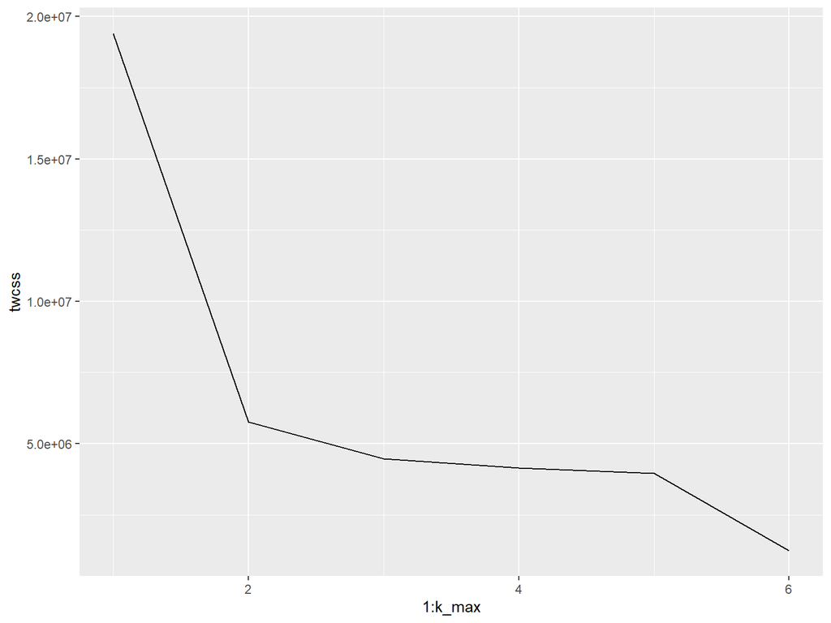

```r
# Calculate the total within sum of squares to find the optimal number of clusters
twcss <- sapply(1:k_max, function(k){kmeans(Boston, k)$tot.withinss})

# Visualize the results
qplot(x = 1:k_max, y = twcss, geom = 'line')
```

```r
# K-means clustering
km2 <-kmeans(Boston, centers = 2)
summary(km2)
```

```
##              Length Class  Mode
## cluster      506    -none- numeric
## centers       28    -none- numeric
## totss          1    -none- numeric
## withinss       2    -none- numeric
## tot.withinss   1    -none- numeric
## betweenss      1    -none- numeric
## size           2    -none- numeric
## iter           1    -none- numeric
## ifault         1    -none- numeric
```

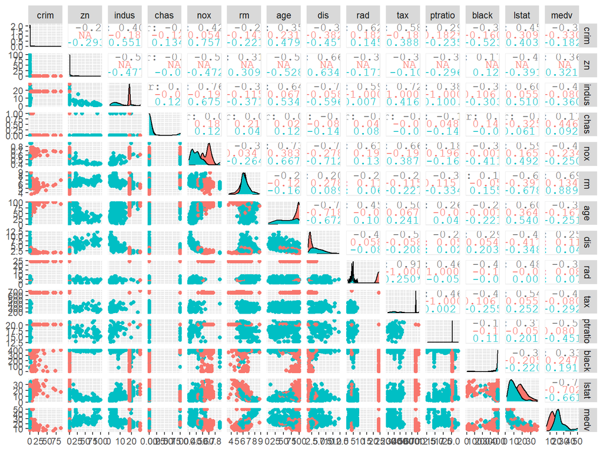

```r
# Visualization by ggpairs, using different colours for different clusters
cluster2 <- as.factor(km2$cluster)
ggpairs(Boston, mapping = aes(col = cluster2))
```

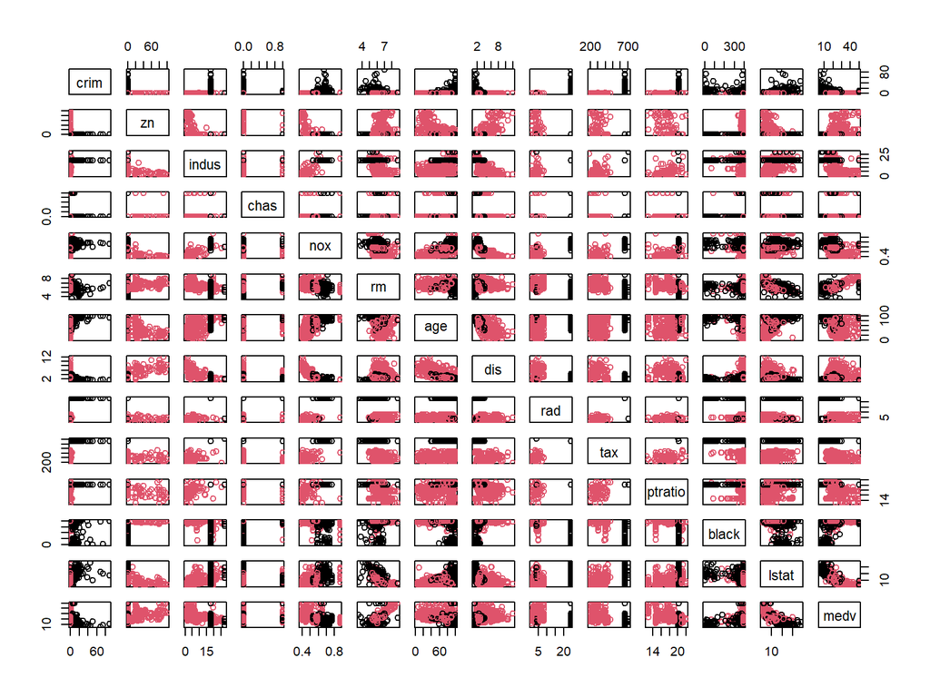

```r
# Same with pairs function, not quite as pretty
pairs(Boston, col = cluster2)
```

# 5: Dimensionality reduction techniques

**Part 1**

Let’s explore the data and plot out the possible correlations!

```r
# Libraries
library(dplyr); library(GGally);library(corrplot)

# Fetching the wrangled data
human <- read.table("data/human.txt")

glimpse(human)
```

```
## Rows: 155
## Columns: 8
## $ Edu_ratio      <dbl> 1.0072389, 0.9968288, 0.9834369, 0.9886128, 0.969060...
## $ Labour_ratio   <dbl> 0.8908297, 0.8189415, 0.8251001, 0.8840361, 0.828611...
## $ Edu            <dbl> 17.5, 20.2, 15.8, 18.7, 17.9, 16.5, 18.6, 16.5, 15.9...
## $ Life           <dbl> 81.6, 82.4, 83.0, 80.2, 81.6, 80.9, 80.9, 79.1, 82.0...
## $ GNI            <int> 64992, 42261, 56431, 44025, 45435, 43919, 39568, 529...
## $ Maternal_mort  <int> 4, 6, 6, 5, 6, 7, 9, 28, 11, 8, 6, 4, 8, 4, 27, 2, 1...
## $ Adol_birth     <dbl> 7.8, 12.1, 1.9, 5.1, 6.2, 3.8, 8.2, 31.0, 14.5, 25.3...
## $ Representation <dbl> 39.6, 30.5, 28.5, 38.0, 36.9, 36.9, 19.9, 19.4, 28.2...
```

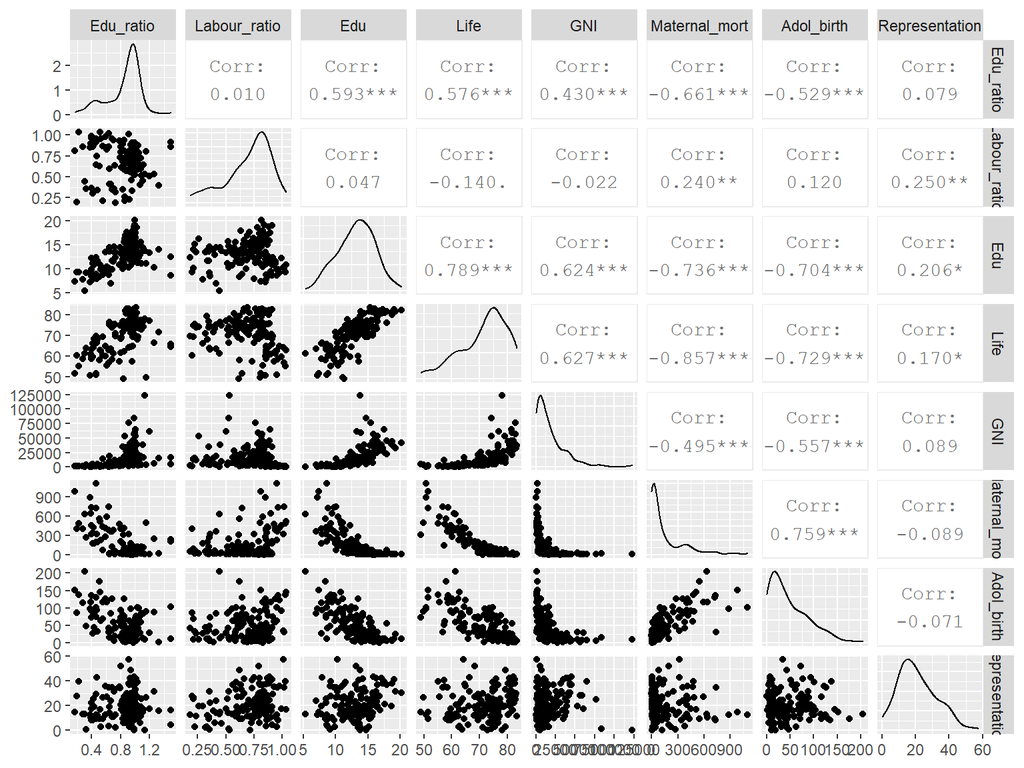

```r
ggpairs(human)
```

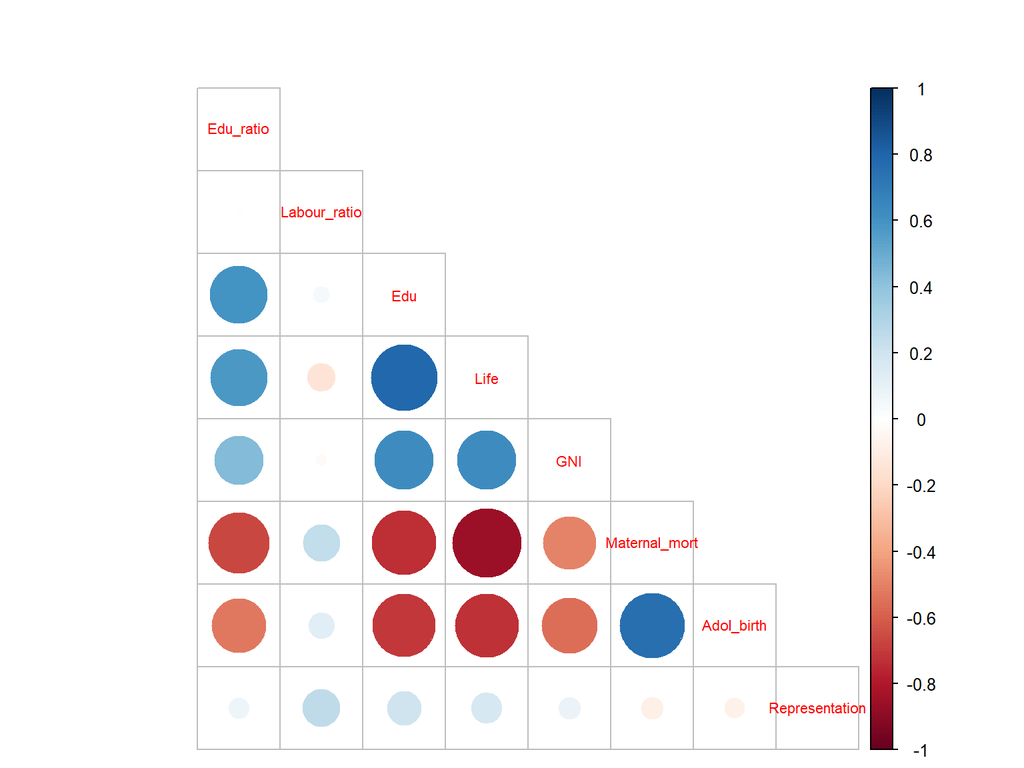

```r
cor(human) %>% corrplot (type = "lower", tl.cex = 0.7, tl.pos="d", cl.pos="r")
```

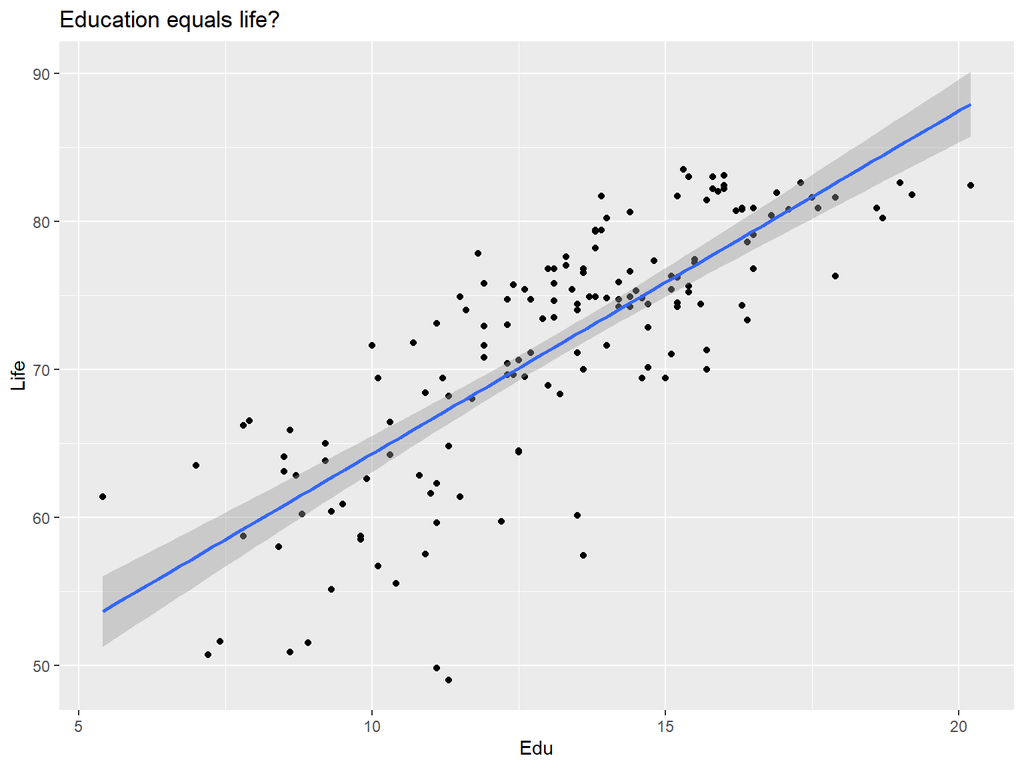

```r
ggplot(human, aes(x = Edu, y = Life)) + geom_point() + geom_smooth(method = "lm") + ggtitle("Education equals life?")
```

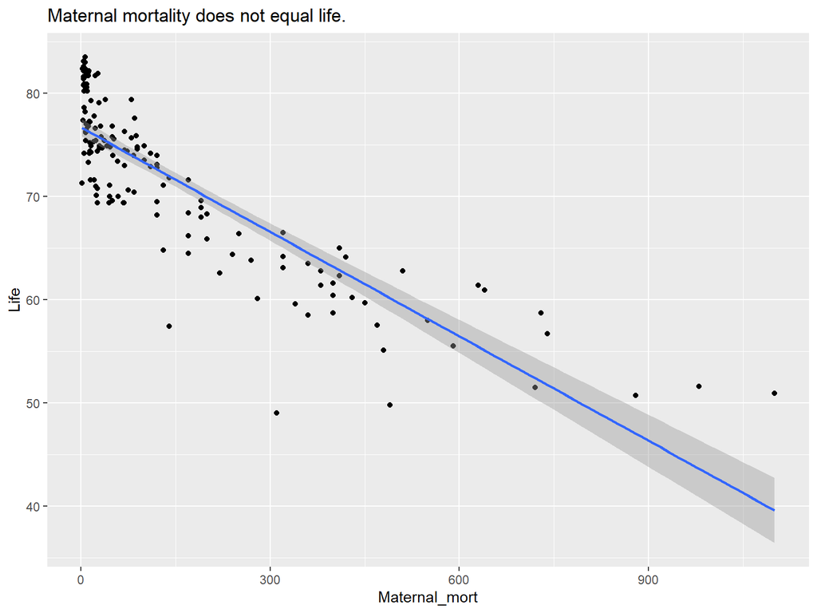

```r
ggplot(human, aes(x = Maternal_mort, y = Life)) + geom_point() + geom_smooth(method = "lm") + ggtitle("Maternal mortality does not equal life.")
```

The highest positive correlations seem to be between education and life expectancy, and between maternal mortality and adolescent bith rate. Strongest negative correlation is between life expectancy and maternal mortality, which kind of makes sense. From the ggpairs we see how the data points plot against each other - the highest positive and negative correlation pairs seem like good candidates for fitting some nice linear regression lines to them, so I did. I did not bother to analyze these plots or the fitted lines’ intercepts any further, though - this exercise is, after all, about multivariate analysis.

**Part 2**

First, we perform PCA (principal component analysis) to the unaltered data:

```r
# PCA (with the SVD method)
pca_human1 <- prcomp(human)
summary(pca_human1)
```

```
## Importance of components:
##                              PC1      PC2   PC3   PC4   PC5   PC6    PC7    PC8
## Standard deviation     1.854e+04 185.5219 25.19 11.45 3.766 1.566 0.1912 0.1591
## Proportion of Variance 9.999e-01   0.0001  0.00  0.00 0.000 0.000 0.0000 0.0000
## Cumulative Proportion  9.999e-01   1.0000  1.00  1.00 1.000 1.000 1.0000 1.0000
```

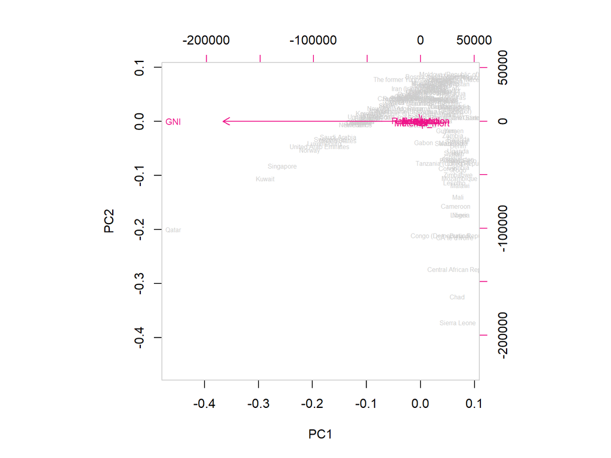

```r
# Biplot of the PC representation and the original variables
biplot(pca_human1, choices = 1:2, cex = c(0.5, 0.7), col = c("grey80", "deeppink2"))
```

The variable GNI completely dominates and explains all the variation in the raw data, as the numerical values of GNI are so huge in comparison to the other variables. Thus, we need to standardize the data to get more meaningful results from this analysis.

**Part 3**

Let’s scale the data, perform the analysis again, and name our biplot labels according to the variance percentages!

```r
# Scaling the data and performing the PCA analysis again
human_s <- scale(human)
pca_human <- prcomp(human_s)

summary(pca_human)
```

```
## Importance of components:
##                           PC1    PC2     PC3     PC4     PC5     PC6     PC7
## Standard deviation     2.0708 1.1397 0.87505 0.77886 0.66196 0.53631 0.45900
## Proportion of Variance 0.5361 0.1624 0.09571 0.07583 0.05477 0.03595 0.02634
## Cumulative Proportion  0.5361 0.6984 0.79413 0.86996 0.92473 0.96069 0.98702
##                            PC8
## Standard deviation     0.32224
## Proportion of Variance 0.01298
## Cumulative Proportion  1.00000
```

```r
# Calculate and print rounded percentages of variance
s <- summary(pca_human)
pca_p <- round(1*s$importance[2, ]*100, digits = 1)
pca_p
```

```
##  PC1  PC2  PC3  PC4  PC5  PC6  PC7  PC8
## 53.6 16.2  9.6  7.6  5.5  3.6  2.6  1.3
```

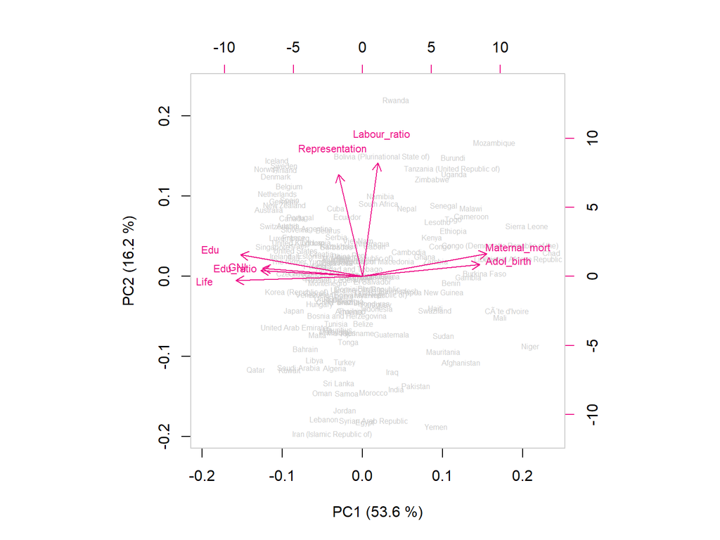

```r
# Assign corresponding percentages to labels
pc_l <- paste0(names(pca_p), " (", pca_p, " %)")

# Scaled biplot with corresponding variance percentages in labels
biplot(pca_human, choices = 1:2, cex = c(0.5, 0.7), col = c("grey80", "deeppink2"), xlab = pc_l[1], ylab = pc_l[2])
```

Now the data is much more readable.

**Part 4**

We can see that the principal component 1 explains up to 53,6 % of the variation, and it consists of variables such as life expectancy and educational factors. Gender factors, such as labour ratio and representation in the parliament, explain 16,2 % of the variation. Education, life expectancy and GNI cluster to the far left of the biplot, and maternal mortality and adolescent birth ratio to the far right, and from the arrows we can see that they have opposing effects.

**Part 5**

Here we explore data of tea drinking habits from FactoMineR library. The original dataset contains 36 different variables (see colnames below for the full list), but I decided to separate the data containing information about tea drinking places, the type of tea (earl grey, green or black) and age quartales (the variable age_G) for a closer look. We visualize these selected variables and their internal distribution by simple column charts, and then perform Multiple Correspondence Analysis (MCA) to see if any patterns can be interpreted.

```r
library(FactoMineR); library(tidyr)
data("tea")
colnames(tea)
```

```
##  [1] "breakfast"        "tea.time"         "evening"          "lunch"
##  [5] "dinner"           "always"           "home"             "work"
##  [9] "tearoom"          "friends"          "resto"            "pub"
## [13] "Tea"              "How"              "sugar"            "how"
## [17] "where"            "price"            "age"              "sex"
## [21] "SPC"              "Sport"            "age_Q"            "frequency"
## [25] "escape.exoticism" "spirituality"     "healthy"          "diuretic"
## [29] "friendliness"     "iron.absorption"  "feminine"         "sophisticated"
## [33] "slimming"         "exciting"         "relaxing"         "effect.on.health"
```

```r
teaplaces <- tea[,c(7:13,23)]

colnames(teaplaces)
```

```
## [1] "home"    "work"    "tearoom" "friends" "resto"   "pub"     "Tea"
## [8] "age_Q"
```

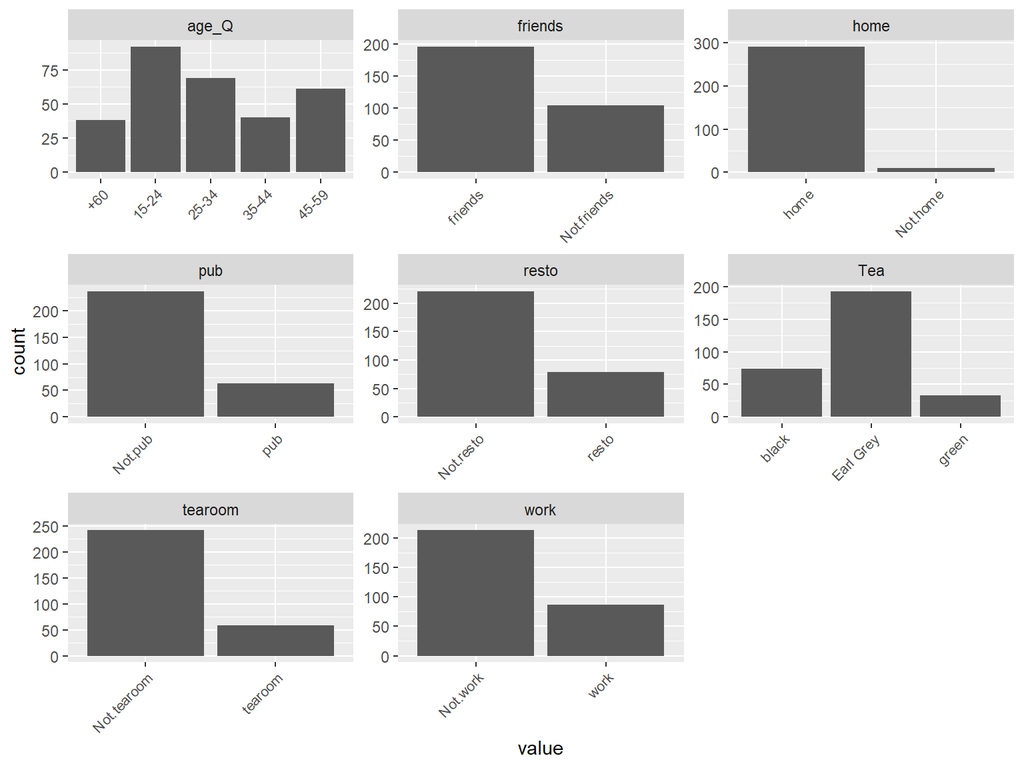

```r
gather(teaplaces) %>% ggplot(aes(value)) + facet_wrap("key", scales = "free") + geom_bar() + theme(axis.text.x = element_text(angle = 45, hjust = 1, size = 8))
```

```r
mca <- MCA(teaplaces, graph = F)
summary(mca)
```

```
##
## Call:
## MCA(X = teaplaces, graph = F)
##
##
## Eigenvalues
##                        Dim.1   Dim.2   Dim.3   Dim.4   Dim.5   Dim.6   Dim.7
## Variance               0.226   0.176   0.161   0.143   0.132   0.127   0.114
## % of var.             15.061  11.703  10.764   9.546   8.769   8.484   7.568
## Cumulative % of var.  15.061  26.763  37.527  47.074  55.843  64.328  71.895
##                        Dim.8   Dim.9  Dim.10  Dim.11  Dim.12
## Variance               0.104   0.086   0.081   0.079   0.071
## % of var.              6.939   5.763   5.368   5.284   4.750
## Cumulative % of var.  78.834  84.597  89.966  95.250 100.000
##
## Individuals (the 10 first)
##                Dim.1    ctr   cos2    Dim.2    ctr   cos2    Dim.3    ctr
## 1           | -0.565  0.471  0.200 |  0.462  0.406  0.134 |  0.170  0.059
## 2           | -0.659  0.640  0.342 |  0.295  0.165  0.068 |  0.208  0.089
## 3           |  0.481  0.341  0.171 |  0.055  0.006  0.002 |  0.439  0.397
## 4           | -0.331  0.162  0.146 | -0.501  0.477  0.335 | -0.258  0.137
## 5           | -0.461  0.313  0.222 | -0.194  0.071  0.039 |  0.208  0.089
## 6           | -0.331  0.162  0.146 | -0.501  0.477  0.335 | -0.258  0.137
## 7           | -0.065  0.006  0.004 | -0.008  0.000  0.000 | -0.007  0.000
## 8           | -0.565  0.471  0.200 |  0.462  0.406  0.134 |  0.170  0.059
## 9           | -0.367  0.199  0.105 | -0.026  0.001  0.001 |  0.170  0.059
## 10          | -0.276  0.113  0.037 |  0.840  1.340  0.339 |  0.104  0.022
##               cos2
## 1            0.018 |
## 2            0.034 |
## 3            0.143 |
## 4            0.088 |
## 5            0.045 |
## 6            0.088 |
## 7            0.000 |
## 8            0.018 |
## 9            0.023 |
## 10           0.005 |
##
## Categories (the 10 first)
```

[output cut: 18 more lines]

```
## friends     -0.197  1.963  0.073 -4.676 |
## Not.friends  0.371  3.699  0.073  4.676 |
## Not.resto   -0.058  0.192  0.009 -1.677 |
## resto        0.162  0.537  0.009  1.677 |
##
## Categorical variables (eta2)
##               Dim.1 Dim.2 Dim.3
## home        | 0.014 0.017 0.193 |
## work        | 0.276 0.000 0.244 |
## tearoom     | 0.188 0.250 0.007 |
## friends     | 0.297 0.001 0.073 |
## resto       | 0.316 0.129 0.009 |
## pub         | 0.249 0.000 0.124 |
## Tea         | 0.332 0.479 0.006 |
## age_Q       | 0.135 0.527 0.635 |
```

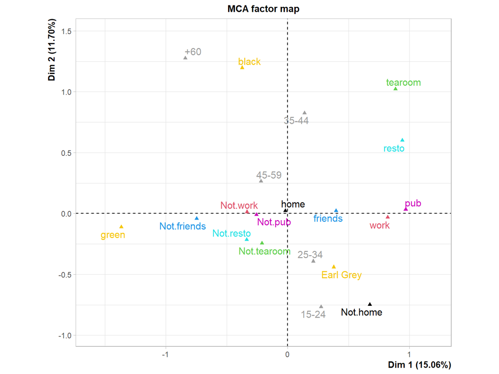

```r
plot(mca, invisible=c("ind"), habillage = "quali")
```

# 6: Analysis of longitudinal data

For the last exercise, we wrangled two datasets into long form from the original wide form, in order to allow us to perform analysis on them.

Basically this means that we broke joined data in columns (we had certain time intervals as colums containing the corresponding measured results) to separate these time periods to their own column, resulting in four variables for each set; “treatment”, “subject”, “bprs” and “week” for BPRS dataset, describing response in measured BPRS test results to two different treatments to schizophrenia; and “ID”, “Group”, “Weight” and “Time” in RATS data which investigates measured rat weights after starting one of three possible diet groups.

As “week” and “time” are now their own variables, instead of “week0, week1, week2” etc., we can perform analysis that shows us measured responses over time. I ended up adding a new column, id, to the BPRS data, as this allowed me to plot different treatment groups simultaneously - the two treatment groups contained identical 1-20 subjects, whereas the new id category treats each individual response to a certain treatment as unique.

```r
library(dplyr); library(ggplot2); library(lme4)

# Fetching the wrangled data
data_B <- read.table("data/bprs.txt")
data_R <- read.table("data/rats.txt")

# Assigning separate ID:s for same subjects but different treatments
# so that we have ID:s 1-20 for treatment 1 and 21-40 for treatment 2
data_B$subject <- as.integer(data_B$subject)
data_B$id <-
  ifelse(data_B$treatment==1,
         data_B$subject,data_B$subject+20)

# Factoring categorical variables again, as R interprets them as integers
data_B$treatment <- factor(data_B$treatment)
data_B$subject <- factor(data_B$subject)
data_R$ID <- factor(data_R$ID)
data_R$Group <- factor(data_R$Group)

# Glimpse of the data
glimpse(data_B)
```

```
## Rows: 360
## Columns: 5
## $ treatment <fct> 1, 1, 1, 1, 1, 1, 1, 1, 1, 1, 1, 1, 1, 1, 1, 1, 1, 1, 1, ...
## $ subject   <fct> 1, 2, 3, 4, 5, 6, 7, 8, 9, 10, 11, 12, 13, 14, 15, 16, 17...
## $ bprs      <int> 42, 58, 54, 55, 72, 48, 71, 30, 41, 57, 30, 55, 36, 38, 6...
## $ week      <int> 0, 0, 0, 0, 0, 0, 0, 0, 0, 0, 0, 0, 0, 0, 0, 0, 0, 0, 0, ...
## $ id        <dbl> 1, 2, 3, 4, 5, 6, 7, 8, 9, 10, 11, 12, 13, 14, 15, 16, 17...
```

```r
glimpse(data_R)
```

```
## Rows: 176
## Columns: 4
## $ ID     <fct> 1, 2, 3, 4, 5, 6, 7, 8, 9, 10, 11, 12, 13, 14, 15, 16, 1, 2,...
## $ Group  <fct> 1, 1, 1, 1, 1, 1, 1, 1, 2, 2, 2, 2, 3, 3, 3, 3, 1, 1, 1, 1, ...
## $ Weight <int> 240, 225, 245, 260, 255, 260, 275, 245, 410, 405, 445, 555, ...
## $ Time   <int> 1, 1, 1, 1, 1, 1, 1, 1, 1, 1, 1, 1, 1, 1, 1, 1, 8, 8, 8, 8, ...
```

```r
summary(data_B)
```

```
##  treatment    subject         bprs            week         id
##  1:180     1      : 18   Min.   :18.00   Min.   :0   Min.   : 1.00
##  2:180     2      : 18   1st Qu.:27.00   1st Qu.:2   1st Qu.:10.75
##            3      : 18   Median :35.00   Median :4   Median :20.50
##            4      : 18   Mean   :37.66   Mean   :4   Mean   :20.50
##            5      : 18   3rd Qu.:43.00   3rd Qu.:6   3rd Qu.:30.25
##            6      : 18   Max.   :95.00   Max.   :8   Max.   :40.00
##            (Other):252
```

```r
summary(data_R)
```

```
##        ID      Group      Weight           Time
##  1      : 11   1:88   Min.   :225.0   Min.   : 1.00
##  2      : 11   2:44   1st Qu.:267.0   1st Qu.:15.00
##  3      : 11   3:44   Median :344.5   Median :36.00
##  4      : 11          Mean   :384.5   Mean   :33.55
##  5      : 11          3rd Qu.:511.2   3rd Qu.:50.00
##  6      : 11          Max.   :628.0   Max.   :64.00
##  (Other):110
```

**Part 1**

The assignment was to implement the analyses of Chapter 8 of MABS using the RATS data. First, let’s visualize the data with boxplots and line charts of both individual rats, and the mean profiles by diet groups. I also produced line chart for standardized weights.

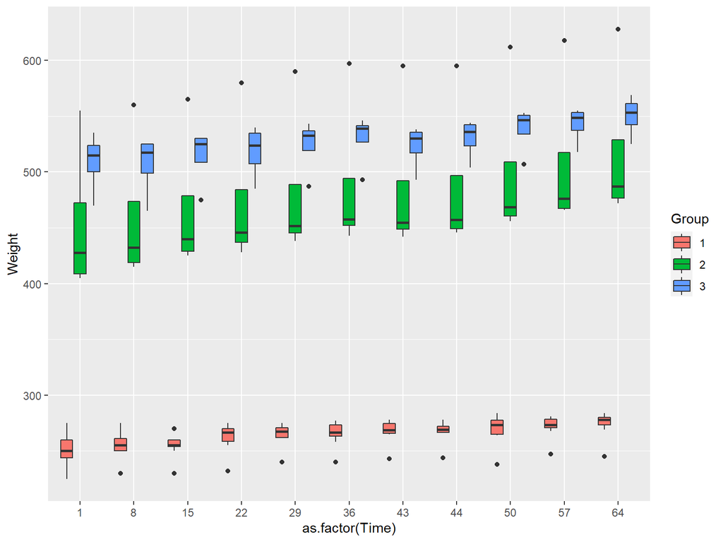

```r
# Boxplot to visualize the raw data
ggplot(data_R, aes(x = as.factor(Time), y = Weight, fill = Group)) +
  geom_boxplot()
```

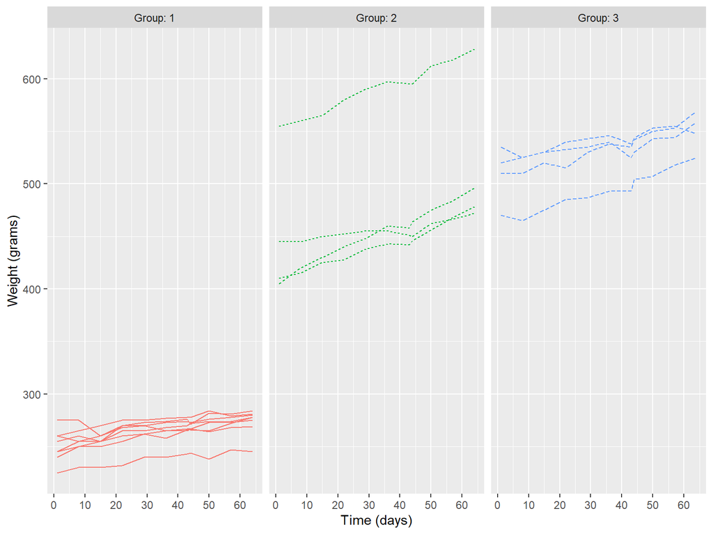

```r
# Plots of individual rat growth profiles within their corresponding groups

ggplot(data_R, aes(x = Time, y = Weight, group = ID, col = Group)) +
  geom_line(aes(linetype = Group)) +
  facet_grid(. ~ Group, labeller = label_both) +
  scale_x_continuous(name = "Time (days)", breaks = seq(0, 60, 10)) +
  scale_y_continuous(name = "Weight (grams)") +
  theme(legend.position = "none")
```

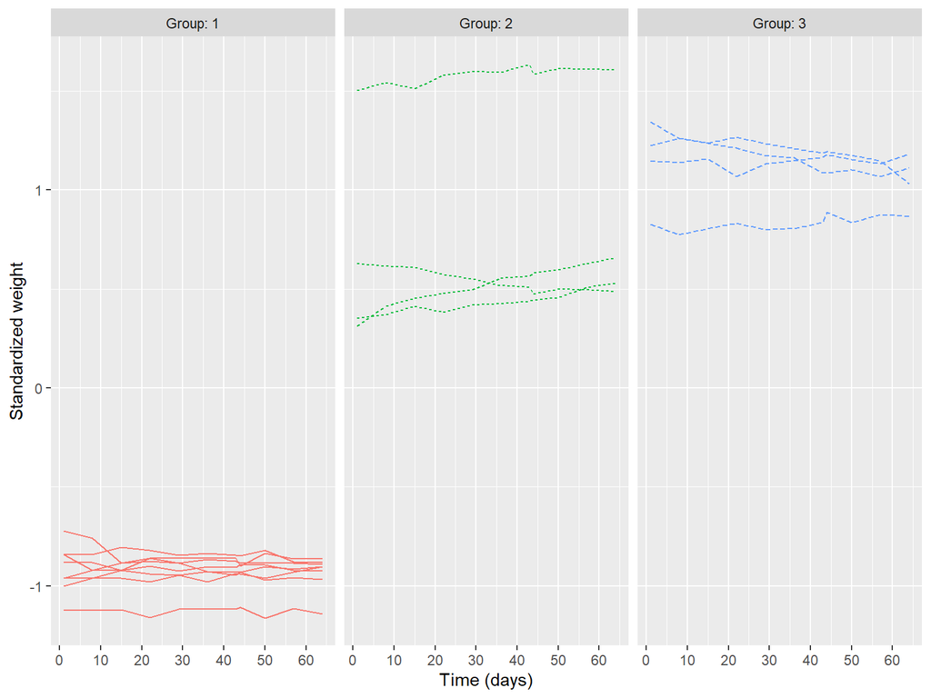

```r
# Standardizing weight

data_R <- data_R %>%
  group_by(Time) %>%
  mutate(Weight_std = (Weight - mean(Weight))/sd(Weight) ) %>%
  ungroup()

# Plotting again with standardized weights

ggplot(data_R, aes(x = Time, y = Weight_std, group = ID, col = Group)) +
  geom_line(aes(linetype = Group)) +
  facet_grid(. ~ Group, labeller = label_both) +
  scale_x_continuous(name = "Time (days)", breaks = seq(0, 60, 10)) +
  scale_y_continuous(name = "Standardized weight") +
  theme(legend.position = "none")
```

The standardized values plot shows that the starting weight tends to affect the end weight (this is called “tracking phenomenon”) - the heaviest rats in the beginning are still heaviest by the end of the experiment, and thinnest stay among the thinnest. Let’s plot mean weights by group against time, with standard error (se) calculated by the following equation:

$$se=\frac{sd(x)}{\sqrt{n}}$$

```r
# Summary data with mean and standard error of weight by group and time
n <- data_R$Time %>% unique() %>% length()

rats_s <- data_R %>%
  group_by(Group, Time) %>%
  summarise( mean = mean(Weight), se = sd(Weight)/sqrt(n) ) %>%
  ungroup()
# Glimpse the data
glimpse(rats_s)
```

```
## Rows: 33
## Columns: 4
## $ Group <fct> 1, 1, 1, 1, 1, 1, 1, 1, 1, 1, 1, 2, 2, 2, 2, 2, 2, 2, 2, 2, 2...
## $ Time  <int> 1, 8, 15, 22, 29, 36, 43, 44, 50, 57, 64, 1, 8, 15, 22, 29, 3...
## $ mean  <dbl> 250.625, 255.000, 254.375, 261.875, 264.625, 265.000, 267.375...
## $ se    <dbl> 4.589478, 3.947710, 3.460116, 4.100800, 3.333956, 3.552939, 3...
```

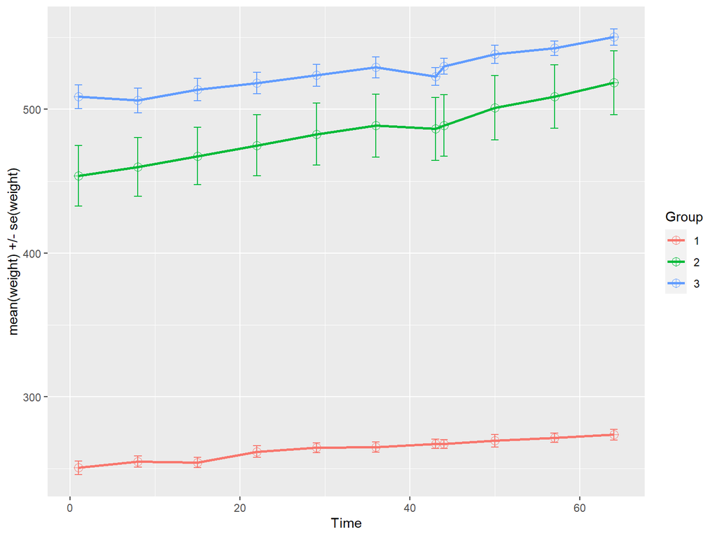

```r
# Plot the mean profiles
ggplot(rats_s, aes(x = Time, y = mean, col = Group)) +
  geom_line(size=1) +
  geom_point(size=3, shape=10) +
  geom_errorbar(aes(ymin = mean - se, ymax = mean + se)) +
  scale_y_continuous(name = "mean(weight) +/- se(weight)")
```

So, in group 2 there is this one very heavy rat that gives the mean values in the second group much bigger error than the other two groups have. Otherwise the groups are nicely sorted by weight - thin rats in group 1, heaviest ones in group 3 (except for this one humongous rat in group 2). All groups tend to gain weight on their corresponding diets.

Next, let’s draw boxplots of the mean weights by group after day one (which is the baseline).

```r
# Summary dataset by treatment and subject with mean as the summary variable (ignoring baseline Time = 1).
rats_sum <- data_R %>%
  filter(Time > 1) %>%
  group_by(Group, ID) %>%
  summarise( mean=mean(Weight) ) %>%
  ungroup()
# Glimpse the data
glimpse(rats_sum)
```

```
## Rows: 16
## Columns: 3
## $ Group <fct> 1, 1, 1, 1, 1, 1, 1, 1, 2, 2, 2, 2, 3, 3, 3, 3
## $ ID    <fct> 1, 2, 3, 4, 5, 6, 7, 8, 9, 10, 11, 12, 13, 14, 15, 16
## $ mean  <dbl> 263.2, 238.9, 261.7, 267.2, 270.9, 276.2, 274.6, 267.5, 443.9...
```

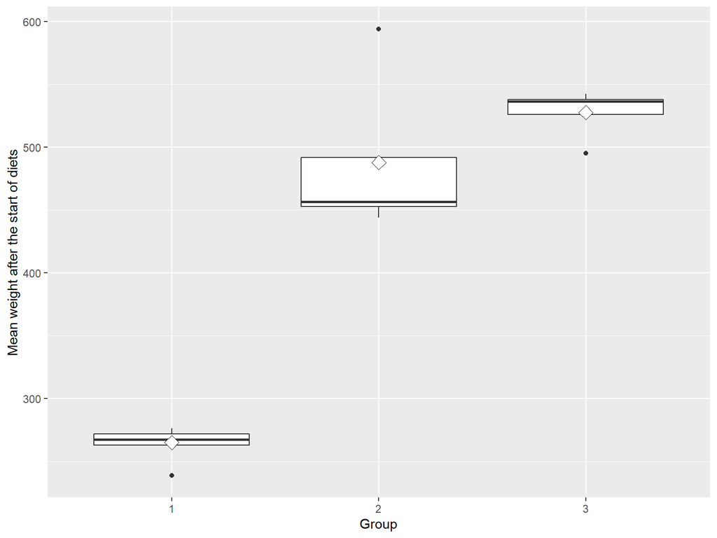

```r
# Draw a boxplot of the mean versus treatment
ggplot(rats_sum, aes(x = Group, y = mean)) +
  geom_boxplot() +
  stat_summary(fun = "mean", geom = "point", shape=23, size=4, fill = "white") +
  scale_y_continuous(name = "Mean weight after the start of diets")
```

There are three outliers in this data. Let’s see how the plots look like if we exclude these outliers:

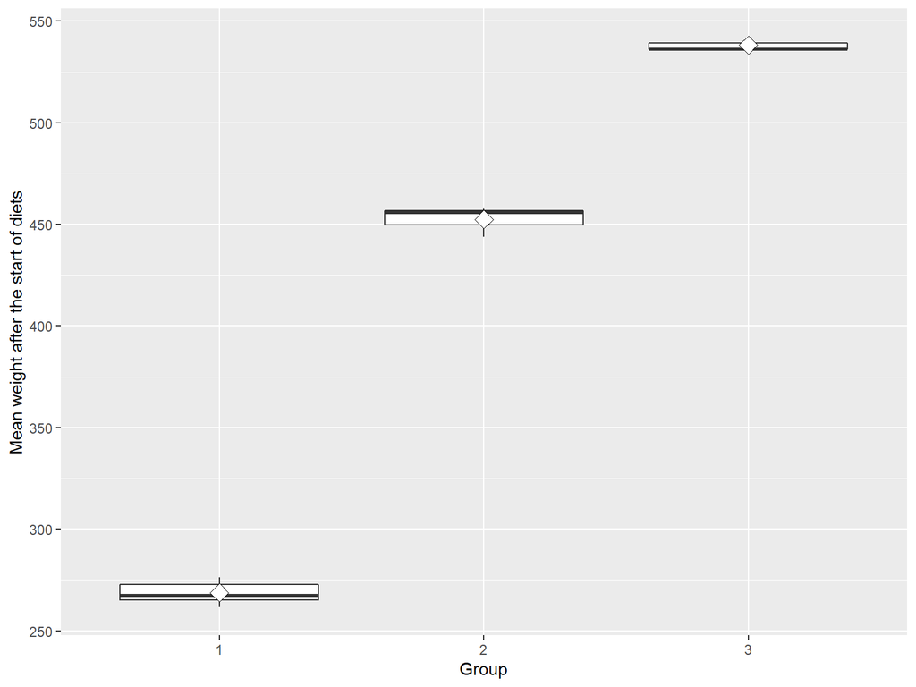

```r
# Creating a new dataset by filtering the three outliers
rats_sum2 <- rats_sum %>%
  filter(ID!=2 & ID!=12 & ID!=13)  # Outlier ID's

ggplot(rats_sum2, aes(x = Group, y = mean)) +
  geom_boxplot() +
  stat_summary(fun = "mean", geom = "point", shape=23, size=4, fill = "white") +
  scale_y_continuous(name = "Mean weight after the start of diets")
```

Now the box plots are much less deviated by these outlier rats. Finally, let’s compute analysis of variance (anova) tables for this data with and without baseline weight (weight at day 1 from the original data).

```r
# Analysis of variance table for the fitted model, without baselines
anova(lm(mean ~ Group, data = rats_sum2))
```

```
## Analysis of Variance Table
##
## Response: mean
##           Df Sum Sq Mean Sq F value    Pr(>F)
## Group      2 176917   88458  2836.4 1.687e-14 ***
## Residuals 10    312      31
## ---
## Signif. codes:  0 '***' 0.001 '**' 0.01 '*' 0.05 '.' 0.1 ' ' 1
```

```r
# Adding the baseline from the original data as a new variable
baselines <-
  data_R %>% filter(Time==1) %>%
  rename(baseline=Weight)

rats_b <- rats_sum %>%
  mutate(baselines) %>%
  filter(ID!=2 & ID!=12 & ID!=13)  # Outlier ID's

# Analysis of variance table for the fitted model, with baselines
anova(lm(mean ~ Group + baseline, data = rats_b))
```

```
## Analysis of Variance Table
##
## Response: mean
##           Df Sum Sq Mean Sq   F value    Pr(>F)
## Group      2 176917   88458 3353.2062 1.181e-13 ***
## baseline   1     74      74    2.8219    0.1273
## Residuals  9    237      26
## ---
## Signif. codes:  0 '***' 0.001 '**' 0.01 '*' 0.05 '.' 0.1 ' ' 1
```

The diet group’s mean weight difference is statistically significant, at p value well under 0,05. In the baseline including analysis, we see that “baseline” weight doesn’t affect this result, and “baseline” variable is not statistically significant in this model. As the rats were apparently assigned to the groups by their starting weight (save for the mega rat in group 2, that we excluded from this analysis), their baseline weight corresponds roughly to the group mean weight, and thus this result makes sense.